# Contrapuntal Duos With CRIM Intervals

Author

Richard Freedman

Published

February 28, 2025

## 1. Import Python Libraries

An essential first step . . .

```python
# python imports
from crim_intervals import *
from crim_intervals import importScore
from crim_intervals import main_objs
from community import community_louvain
from copy import deepcopy
from IPython.display import SVG
from collections import Counter
import altair as alt
import glob as glob
import crim_intervals
import crim_intervals.visualizations as viz
import numpy as np
import math

import os
import pandas as pd
import re
import networkx as nx
import requests





MYDIR = ("saved_csv")
CHECK_FOLDER = os.path.isdir(MYDIR)

# If folder doesn't exist, then create it.
if not CHECK_FOLDER:
    os.makedirs(MYDIR)
    # print("created folder : ", MYDIR)

# else:
#     print(MYDIR, "folder already exists.")

MUSDIR = ("MEI")
CHECK_FOLDER = os.path.isdir(MUSDIR)

# If folder doesn't exist, then create it.
if not CHECK_FOLDER:
    os.makedirs(MUSDIR)
    # print("created folder : ", MUSDIR)

# else:
#     print(MUSDIR, "folder already exists.")

# code for Quarto and the charting tools
alt.renderers.enable('default')
import plotly.io as pio
pio.renderers.default = "plotly_mimetype+notebook_connected"

import warnings
warnings.filterwarnings('ignore')
```

## 1b. Import Functions

**Do not edit these!**

Just run the cell below!

```python
# functions to load
# run this cell but don't edit it!


def extract_letter(value):
    # Find the index of the first digit
    if value is not None:
        for i, char in enumerate(value):
            if char.isdigit():
                # Return everything before the first digit
                return value[:i]
        # If no digit is found, return the entire string
        return value


def extract_descending(interval):
        """
        Extract descending interval value.

        Parameters:
        -----------
        interval : str
            Interval string

        Returns:
        --------
        int
            Extracted interval value
        """
        match = re.search(r'-?\d+', interval)
        return int(match.group())


def extract_and_sort_reverse(items):
    """
    Extract numbers from items and sort in reverse order.

    Parameters:
    -----------
    items : list
        List of items to sort

    Returns:
    --------
    list
        Sorted list
    """
    # Function to extract numeric part
    def extract_num(item):
        match = re.search(r'[-+]?\d+', item)
        return int(match.group()) if match else 0

    # Extract numbers and sort
    sorted_neg_items = sorted(items, key=extract_num, reverse=True)
    return sorted_neg_items


def extract_and_sort_forward(items):
    """
    Extract numbers from items and sort in forward order.

    Parameters:
    -----------
    items : list
        List of items to sort

    Returns:
    --------
    list
        Sorted list
    """
    # Function to extract numeric part
    def extract_num(item):
        match = re.search(r'[-+]?\d+', item)
        return int(match.group()) if match else 0

    # Extract numbers and sort
    sorted_items = sorted(items, key=extract_num, reverse=False)
    return sorted_items


def extract_letter(value):
    """
    Extract letter part from a value.

    Parameters:
    -----------
    value : str
        String value to extract from

    Returns:
    --------
    str
        Extracted letter part
    """
    # Find the index of the first digit
    if value is not None:
        for i, char in enumerate(value):
            if char.isdigit():
                # Return everything before the first digit
                return value[:i]
        # If no digit is found, return the entire string
        return value
    return None


def convert_tuple(tup):
    """
    Convert tuple to string.

    Parameters:
    -----------
    tup : tuple
        Tuple to convert

    Returns:
    --------
    str
        Converted string
    """
    out = ""
    if isinstance(tup, tuple):
        out = '_'.join(tup)
    return out

# notes in a corpus
def corpus_notes(corpus, combine_unisons_choice, combine_rests_choice):
    func = ImportedPiece.notes  # <- NB there are no parentheses here
    list_of_dfs = corpus.batch(func = func,
                                kwargs = {'combineUnisons': combine_unisons_choice, 'combineRests': combine_rests_choice},
                                metadata=False)
    func1 = ImportedPiece.numberParts
    list_of_dfs = corpus.batch(func = func1,
                               kwargs = {'df' : list_of_dfs},
                               metadata=True)


    nr = pd.concat(list_of_dfs)
    cols_to_move = ['Composer', 'Title', 'Date']
    nr = nr[cols_to_move + [col for col in nr.columns if col not in cols_to_move]]
    return nr


# counting notes (just the number of occurences

def corpus_note_dfs(corpus, combine_unisons_choice, combine_rests_choice):
    func = ImportedPiece.notes  # <- NB there are no parentheses here
    list_of_dfs = corpus.batch(func = func,
                                kwargs = {'combineUnisons': combine_unisons_choice,
                                          'combineRests': combine_rests_choice},
                                metadata=False)
    func1 = ImportedPiece.numberParts
    list_of_dfs = corpus.batch(func = func1,
                               kwargs = {'df' : list_of_dfs},
                               metadata=True)
    final_list_dfs = []
    for df in list_of_dfs:
        # clean up
        df = df.map(lambda x: '' if x == 'Rest' else x).fillna('')
        df['1'] = df['1'].map(lambda x: x[:-1])
        df['2'] = df['2'].map(lambda x: x[:-1])
        df = df[df.index != '']

        stacked_df = df.set_index(['Composer', 'Title', 'Date']).stack()
        counted_notes = Counter(stacked_df)
        first_key = next(iter(counted_notes))
        counted_notes.pop(first_key)

        total_n = sum(counted_notes.values())

        counted_notes = pd.Series(counted_notes).to_frame('count').sort_index()
        counted_notes['scaled'] = counted_notes['count'] / total_n
        counted_notes['scaled'] = counted_notes['scaled'].round(2)
        counted_notes.rename(columns={"count": "count", "scaled": "scaled_count"}, inplace=True)

        counted_notes['Composer'] = df.iloc[0]['Composer']
        counted_notes['Title'] = df.iloc[0]['Title']
        counted_notes = counted_notes[counted_notes.index != '']
        final_list_dfs.append(counted_notes)

    corpus_notes_counts = pd.concat(final_list_dfs)

    return corpus_notes_counts
# notes weighted by duration

def corpus_note_weights(corpus):
    # melted_notes = piece.notes().melt()
    # melted_durations = piece.durations().melt()
    # note_dur = pd.merge(melted_notes, melted_durations, left_index=True, right_index=True)
    # note_dur = note_dur.dropna()

    func = ImportedPiece.notes  # <- NB there are no parentheses here
    list_of_note_dfs = corpus.batch(func = func,
                                    metadata=True)
    func2 = ImportedPiece.durations  # <- NB there are no parentheses here
    list_of_dur_dfs = corpus.batch(func = func2,
                                    metadata=False)
    zipped_dfs = zip(list_of_note_dfs,  list_of_dur_dfs)

    weighted_note_dfs = []
    for a, b in zipped_dfs:
        # get metadata
        first_row = a.iloc[1]
        columns_of_interest = ['Composer', 'Title']
        metadata = first_row[columns_of_interest].tolist()

        # drop the same columns (we will add them back later)
        a = a.drop(columns=['Composer', 'Title', 'Date'])
        melted_notes = a.melt()
        melted_durs = b.melt()
        note_dur = pd.merge(melted_notes, melted_durs, left_index=True, right_index=True)
        note_dur = note_dur.dropna()
        note_dur['value_x_clean'] = note_dur['value_x'].apply(extract_letter)
        # Apply the function to the DataFrame
        note_dur['value_x_clean'] = note_dur['value_x'].apply(extract_letter)
        note_dur_sums = pd.DataFrame(note_dur.groupby('value_x_clean')['value_y'].sum()).reset_index(drop=False)
        # total (for scaled calculation)
        total_dur = note_dur_sums['value_y'].sum()
        note_dur_sums['scaled'] = note_dur_sums['value_y'].apply(lambda x: x/total_dur).round(2)
        note_dur_sums.rename(columns={"value_x_clean": "pitch_class", "value_y": "count"}, inplace=True)
        # pitch class order defined above
        note_dur_sums['pitch_class'] = pd.Categorical(note_dur_sums['pitch_class'], categories=pitch_class_order, ordered=True)
        # Sort the DataFrame
        sorted_df = note_dur_sums.sort_values('pitch_class')
        weighted_notes = sorted_df.dropna()
        weighted_notes['piece'] = metadata[0] + ': ' + metadata[1]
        weighted_note_dfs.append(weighted_notes)
        corpus_note_weights = pd.concat(weighted_note_dfs)
    return corpus_note_weights

# melodic intervals in a corpus
def corpus_mel(corpus, kind_choice, compound_choice):
    func = ImportedPiece.melodic  # <- NB there are no parentheses here
    list_of_dfs = corpus.batch(func = func,
                                kwargs = {'kind': kind_choice,
                                         'compound' : compound_choice},
                                metadata=False)
    func1 = ImportedPiece.numberParts
    list_of_dfs = corpus.batch(func = func1,
                               kwargs = {'df' : list_of_dfs},
                               metadata=True)


    mel = pd.concat(list_of_dfs)
    cols_to_move = ['Composer', 'Title', 'Date']
    mel = mel[cols_to_move + [col for col in mel.columns if col not in cols_to_move]]
    return mel

# harmonic intervals in a corpus
def corpus_har(corpus, kind_choice, compound_choice, directed_choice):
    func = ImportedPiece.harmonic  # <- NB there are no parentheses here
    list_of_dfs = corpus.batch(func = func,
                                kwargs = {'kind': kind_choice,
                                         'compound' : compound_choice,
                                         'directed': directed_choice},
                                metadata=False)
    func1 = ImportedPiece.numberParts
    list_of_dfs = corpus.batch(func = func1,
                               kwargs = {'df' : list_of_dfs},
                               metadata=True)


    har = pd.concat(list_of_dfs)
    cols_to_move = ['Composer', 'Title', 'Date']
    har = har[cols_to_move + [col for col in har.columns if col not in cols_to_move]]
    return har

def corpus_ngrams(corpus, ngram_length, combine_rests_choice):
    func = ImportedPiece.ngrams  # <- NB there are no parentheses here
    list_of_dfs = corpus.batch(func = func,
                                kwargs = {'n': ngram_length},
                                metadata=False)
    func1 = ImportedPiece.numberParts
    list_of_dfs = corpus.batch(func = func1,
                               kwargs = {'df' : list_of_dfs},
                               metadata=True)


    ngrams = pd.concat(list_of_dfs)
    cols_to_move = ['Composer', 'Title', 'Date']
    ngrams = ngrams[cols_to_move + [col for col in ngrams.columns if col not in cols_to_move]]
    return ngrams

# variable orders

pitch_order = ['A#1', 'B1',
    'C2', 'C#2', 'D2', 'D#2','E-2', 'E2', 'E#2', 'F2', 'F#2', 'G-2', 'G2', 'G#2', 'A-2', 'A2', 'A#2','B-2', 'B2', 'B#2',
    'C3', 'C#3', 'D-3','D3', 'D#3', 'E-3','E3', 'E#3', 'F3', 'F#3', 'G-3', 'F##3', 'G3', 'G#3', 'A-3', 'A3', 'A#3', 'B-3','B3', 'B#3',
    'C4', 'C#4', 'D-4','D4', 'D#4','E-4', 'E4', 'F-4', 'E#4', 'F4', 'F#4', 'G-4', 'F##4', 'G4', 'G#4', 'A-4','A4', 'A#4', 'B-4', 'B4', 'B#4',
    'C5', 'C#5','C##5', 'D-5','D5', 'D#5', 'E-5','E5', 'F-5','E#5','F5', 'F#5', 'G-5', 'F##5','G5', 'G#5', 'A-5', 'A5', 'A#5', 'B-5', 'B5',
    'C6']

pitch_class_order = ['C', 'C#', 'D-','D', 'D#', 'E-', 'E', 'F-', 'E#', 'F', 'F#', 'G-', 'F##', 'G', 'G#', 'A-','A', 'A#', 'B-', 'B', 'B#']
```

# 2. Import a Score

Here we find a piece to explore.

Load it from the local `MEI` directory:

```python
# pick a local file
file_name = 'MEI/Bach_BWV_0772.mei'

# load a piece object
piece = importScore(file_name)
```

```python
# pick a local file
file_name = 'MEI/Morley_1595_05_Miraculous_loves.mei'

# load a piece object
piece = importScore(file_name)
```

```python
# Check the metadata for this piece
piece.metadata
```

```
{'title': "Miraculous love's wounding, RISM A/I: M 3701.  No. 5",
 'composer': 'Morley, Thomas',
 'date': None}
```

```python
# metadata are organized as a dictionary.  get just the title
piece.metadata['title']
```

```
"Miraculous love's wounding, RISM A/I: M 3701.  No. 5"
```

# 3 Notes, Durations

We call various CRIM Intervals functions on the piece object, like:

```python
piece.notes(). #this shows notes and rests
```

Or:

```python
piece.durations(). #this shows durations
```

- Each voice is a column
- The left-hand index column represents the `offset` of each event: `1.0` corresponds to one quarter note
- The index values are **zero-based**, so each piece starts with `0.0`
- The notes are recorded with as **tone** plus **octave**, such as `G4`
- rests are recorded as `Rest`
- `NaN` occurs when there is a new event in one voice, but not another. We can remove, fill, ignore these as needed

## 3a. Notes

```python
# notes and rests
piece.notes()
```

|  | Soprano | Part-2 |
| --- | --- | --- |
| 0.00 | G4 | Rest |
| 2.00 | B-4 | G4 |
| 3.50 | C5 | NaN |
| 4.00 | D5 | B-4 |
| 5.50 | NaN | C5 |
| ... | ... | ... |
| 261.50 | NaN | A4 |
| 261.75 | NaN | G4 |
| 262.00 | NaN | A4 |
| 263.00 | F#4 | NaN |
| 264.00 | G4 | B4 |

328 rows × 2 columns

## 3b. Durations

```python
# the durations of each note and rest
piece.durations()
```

|  | Soprano | Part-2 |
| --- | --- | --- |
| 0.00 | 2.0 | 2.00 |
| 2.00 | 1.5 | 2.00 |
| 3.50 | 0.5 | NaN |
| 4.00 | 2.0 | 1.50 |
| 5.50 | NaN | 0.50 |
| ... | ... | ... |
| 261.50 | NaN | 0.25 |
| 261.75 | NaN | 0.25 |
| 262.00 | NaN | 2.00 |
| 263.00 | 1.0 | NaN |
| 264.00 | 4.0 | 4.00 |

328 rows × 2 columns

## 3c. Measure and Beat Numbers

Need to see the **measure numbers**? In this case we take the results of `notes_rests` and pass this dataframe to `detailIndex()`

```python
notes_rests = piece.notes().dropna()
piece.detailIndex(df=notes_rests, offset=True)
```

```python
notes_rests = piece.notes().dropna()
piece.detailIndex(df=notes_rests, offset=True)
```

| Measure | Beat | Offset | Soprano | Part-2 |
| --- | --- | --- | --- | --- |
| 1.0 | 1.0 | 0.0 | G4 | Rest |
|  | 3.0 | 2.0 | B-4 | G4 |
| 2.0 | 1.0 | 4.0 | D5 | B-4 |
|  | 3.0 | 6.0 | Rest | D5 |
| 3.0 | 1.0 | 8.0 | F4 | Rest |
| ... | ... | ... | ... | ... |
| 65.0 | 3.0 | 258.0 | B-4 | D5 |
|  | 4.0 | 259.0 | A4 | C5 |
| 66.0 | 1.5 | 260.5 | G4 | B-4 |
|  | 2.0 | 261.0 | G4 | B-4 |
| 67.0 | 1.0 | 264.0 | G4 | B4 |

173 rows × 2 columns

## 3d. Voice Names or Part Numbers?

The column names show the original voice names in your piece, but it is also possible to number these, which is useful if working with a corpus of pieces that might have different voice names. Here is how to do this:

```python
notes_rests = piece.notes().dropna()
notes_rests_num_parts = piece.numberParts(df=notes_rests)
notes_rests_num_parts
```

```python
notes_rests = piece.notes().dropna()
notes_rests_num_parts = piece.numberParts(df=notes_rests)
notes_rests_num_parts
```

|  | 1 | 2 |
| --- | --- | --- |
| 0.0 | G4 | Rest |
| 2.0 | B-4 | G4 |
| 4.0 | D5 | B-4 |
| 6.0 | Rest | D5 |
| 8.0 | F4 | Rest |
| ... | ... | ... |
| 258.0 | B-4 | D5 |
| 259.0 | A4 | C5 |
| 260.5 | G4 | B-4 |
| 261.0 | G4 | B-4 |
| 264.0 | G4 | B4 |

173 rows × 2 columns

# 4. Count and Chart the Notes

Here are various ways to count and display the notes–in the whole piece or in individual voices

## 4a. Melt the Notes and Count Them

```python
# count the notes? first we 'melt' the data to make it 'long data'
melted_notes = notes_rests_num_parts.melt()
melted_notes = melted_notes.rename(columns={'variable': 'voice', 'value': 'pitch'})

melted_notes
```

|  | voice | pitch |
| --- | --- | --- |
| 0 | 1 | G4 |
| 1 | 1 | B-4 |
| 2 | 1 | D5 |
| 3 | 1 | Rest |
| 4 | 1 | F4 |
| ... | ... | ... |
| 341 | 2 | D5 |
| 342 | 2 | C5 |
| 343 | 2 | B-4 |
| 344 | 2 | B-4 |
| 345 | 2 | B4 |

346 rows × 2 columns

```python
# count the pitches with counter is one option
counted_notes = Counter(melted_notes['pitch'])
counted_notes
```

```
Counter({'G4': 37,
         'B-4': 57,
         'D5': 76,
         'Rest': 30,
         'F4': 9,
         'E4': 6,
         'F5': 29,
         'C5': 30,
         'A4': 30,
         'G5': 11,
         'F#4': 6,
         'D4': 5,
         'B4': 6,
         'E5': 11,
         'C#5': 1,
         'E-5': 1,
         'F#5': 1})
```

## 4b. Group the Notes and Display Barchart

```python
# chart of pitches by voice
grouped_data = melted_notes.groupby(['pitch', 'voice']).size().reset_index(name='count')

# Create the stacked bar chart
chart_title = "Distribution of in" + piece.metadata['title']
fig = px.bar(grouped_data,
             x='pitch',
             y='count',
             color='voice',
             barmode='stack',
             title=chart_title,
             # note that we define pitch_order in the helpers file!
             category_orders={'pitch': pitch_order})

fig.update_layout(xaxis_title="Note",
                  yaxis_title="Count",
                  legend_title='Voice',
                  height=500,
                  width=750,
                  xaxis={'categoryorder': 'array', 'categoryarray': pitch_order})

fig.show()
```

[interactive chart not shown]

## 4c. Pitch Class Radar Plot

```python
# First we combine the notes and durations into a single table

melted_notes = piece.notes().melt()
melted_durations = piece.durations().melt()
note_dur = pd.merge(melted_notes, melted_durations, left_index=True, right_index=True)
note_dur = note_dur.dropna()
note_dur.drop(columns=['variable_y'], inplace=True)
note_dur = note_dur.rename(columns={'variable_x': 'voice', 'value_x': 'pitch', 'value_y': 'duration'})
note_dur.head()
```

|  | voice | pitch | duration |
| --- | --- | --- | --- |
| 0 | Soprano | G4 | 2.0 |
| 1 | Soprano | B-4 | 1.5 |
| 2 | Soprano | C5 | 0.5 |
| 3 | Soprano | D5 | 2.0 |
| 5 | Soprano | Rest | 1.0 |

```python
# and now we apply a custom function that reports only the pitch class
# this function was defined above

note_dur['pitch_class'] = note_dur['pitch'].apply(extract_letter)
note_dur
```

|  | voice | pitch | duration | pitch_class |
| --- | --- | --- | --- | --- |
| 0 | Soprano | G4 | 2.00 | G |
| 1 | Soprano | B-4 | 1.50 | B- |
| 2 | Soprano | C5 | 0.50 | C |
| 3 | Soprano | D5 | 2.00 | D |
| 5 | Soprano | Rest | 1.00 | Rest |
| ... | ... | ... | ... | ... |
| 650 | Part-2 | B-4 | 0.50 | B- |
| 651 | Part-2 | A4 | 0.25 | A |
| 652 | Part-2 | G4 | 0.25 | G |
| 653 | Part-2 | A4 | 2.00 | A |
| 655 | Part-2 | B4 | 4.00 | B |

501 rows × 4 columns

```python
# finally, group the data by pitch class and find the total duration
note_dur_sums = pd.DataFrame(note_dur.groupby('pitch_class')['duration'].sum()).reset_index(drop=False)
# also find the total duration of notes in the piece, so we can scale the results
total_dur = note_dur_sums['duration'].sum()
note_dur_sums['scaled'] = note_dur_sums['duration'].apply(lambda x: x/total_dur).round(2)
note_dur_sums['pitch_class'] = pd.Categorical(note_dur_sums['pitch_class'], categories=pitch_class_order, ordered=True)
note_dur_sums
```

|  | pitch_class | duration | scaled |
| --- | --- | --- | --- |
| 0 | A | 56.5 | 0.11 |
| 1 | B | 10.5 | 0.02 |
| 2 | B- | 56.0 | 0.10 |
| 3 | C | 38.0 | 0.07 |
| 4 | C# | 7.0 | 0.01 |
| 5 | D | 147.0 | 0.27 |
| 6 | E | 36.0 | 0.07 |
| 7 | E- | 2.0 | 0.00 |
| 8 | F | 50.5 | 0.09 |
| 9 | F# | 12.0 | 0.02 |
| 10 | G | 89.5 | 0.17 |
| 11 | NaN | 31.0 | 0.06 |

```python
# Single piece plot
fig = px.line_polar(
    note_dur_sums,
    r='scaled',
    theta='pitch_class',
    category_orders={'pitch': pitch_class_order},
    line_close=True,
    range_r=[0, note_dur_sums['scaled'].max() * 1.1],
    markers=True,
    title = 'Weighted Note Distribution in ' + piece.metadata['title'],
    height=600,
    width=600

)

fig.update_traces(
    fill='toself',
    fillcolor='rgba(31, 119, 180, 0.3)',
    line=dict(width=2))
fig.show()
```

[interactive chart not shown]

# 5. Melodic Intervals

## 5a piece.melodic()

This will return all the melodic ‘intervals’ in the piece. You can select the type of interval with the `kind` parameter:

- ‘d’ = diatonic (in which major and minor thirds will simply be ‘3’)
- ‘c’ = chromatic (in which we count every half step between successive notes, in this case a C-G will be ‘7’
- ‘q’ = with quality (in which major thirds will be M3 and minor thirds will be m3, for example)

Learn more at via the [tutorial](https://github.com/HCDigitalScholarship/intervals/blob/main/tutorial/06_Melodic_Intervals.md)

try it:

```python
piece.melodic(kind = 'd').fillna()
```

```python
mel = piece.melodic(kind='d').fillna('')
mel_numb = piece.numberParts(df=mel)
mel_numb
```

|  | 1 | 2 |
| --- | --- | --- |
| 0.00 |  | Rest |
| 2.00 | 3 |  |
| 3.50 | 2 |  |
| 4.00 | 2 | 3 |
| 5.50 |  | 2 |
| ... | ... | ... |
| 261.50 |  | -2 |
| 261.75 |  | -2 |
| 262.00 |  | 2 |
| 263.00 | -2 |  |
| 264.00 | 2 | 2 |

308 rows × 2 columns

```python
# with measure and beat information


mel_measures = piece.detailIndex(df=mel_numb)
mel_measures
```

| Measure | Beat | 1 | 2 |
| --- | --- | --- | --- |
| 1.0 | 1.00 |  | Rest |
|  | 3.00 | 3 |  |
|  | 4.50 | 2 |  |
| 2.0 | 1.00 | 2 | 3 |
|  | 2.50 |  | 2 |
| ... | ... | ... | ... |
| 66.0 | 2.50 |  | -2 |
|  | 2.75 |  | -2 |
|  | 3.00 |  | 2 |
|  | 4.00 | -2 |  |
| 67.0 | 1.00 | 2 | 2 |

308 rows × 2 columns

## 5b piece.harmonic()

- ‘d’ = diatonic (in which major and minor thirds will simply be ‘3’)
- ‘c’ = chromatic (in which we count every half step between successive notes, in this case a C-G will be ‘7’
- ‘q’ = with quality (in which major thirds will be M3 and minor thirds will be m3, for example)

Learn more at via the [tutorial](https://github.com/HCDigitalScholarship/intervals/blob/main/tutorial/07_Harmonic_Intervals.md)

try it:

```python
piece.harmonic(kind = 'd').fillna()
```

```python
har = piece.harmonic(kind = 'd').fillna('')
har_numb = piece.numberParts(df=har)
har_numb
```

|  | 2_1 |
| --- | --- |
| 0.00 | Rest |
| 2.00 | 3 |
| 3.50 | 4 |
| 4.00 | 3 |
| 5.50 | 2 |
| ... | ... |
| 261.50 | -2 |
| 261.75 | 1 |
| 262.00 | -2 |
| 263.00 | -3 |
| 264.00 | -3 |

328 rows × 1 columns

# 6. Ngrams

n-grams are ‘words’ of length ‘n’, and are widely used in the study of textual corpora and other large datasets. In our musical context, these ‘words’ in this case could be anything:

- notes
- durations
- melodic intervals
- harmonic intervals
- even contrapuntal patterns

for example, **ngrams of melodic intervals**; these are the ‘soggetti’ of a piece

```python
mel = piece.melodic(kind='d')
mel_ng = piece.ngrams(df=mel, n=4)
# clean up the tuples as strings
mel_ng_clean = mel_ng.map(convert_tuple)
mel_ng_clean
```

## 6a Melodic ngrams

```python
mel = piece.melodic(kind='d')
mel = piece.numberParts(df=mel)
mel_ng = piece.ngrams(df=mel, n=3)
# clean up the tuples as strings
mel_ng_clean = mel_ng.map(convert_tuple)
mel_ng_clean
```

|  | 1 | 2 |
| --- | --- | --- |
| 2.00 | 3_2_2 |  |
| 4.00 |  | 3_2_2 |
| 8.00 | -2_-2_-2 |  |
| 9.00 | -2_-2_8 |  |
| 10.00 | -2_8_-2 |  |
| ... | ... | ... |
| 259.00 | 2_-2_1 | -2_-2_1 |
| 260.50 | -2_1_-2 | -2_1_-2 |
| 261.00 | 1_-2_2 | 1_-2_-2 |
| 261.50 |  | -2_-2_2 |
| 261.75 |  | -2_2_2 |

276 rows × 2 columns

## 6b Harmonic ngrams

```python
har = piece.harmonic(kind='d', compound=False)
har_ng = piece.ngrams(df=har, n=4)
# clean up the tuples as strings
har_ng_clean = har_ng.map(convert_tuple)
har_ng_clean
```

```python
har = piece.harmonic(kind='d', compound=False)
har = piece.numberParts(df=har)
har_ng = piece.ngrams(df=har, n=4)
# clean up the tuples as strings
har_ng_clean = har_ng.map(convert_tuple)
har_ng_clean
```

|  | 2_1 |
| --- | --- |
| 2.00 | 3_4_3_2 |
| 9.00 | -3_-4_-3_-2 |
| 10.00 | -4_-3_-2_-3 |
| 11.00 | -3_-2_-3_1 |
| 12.00 | -2_-3_1_1 |
| ... | ... |
| 259.00 | -3_-3_-3_-2 |
| 260.50 | -3_-3_-2_1 |
| 261.00 | -3_-2_1_-2 |
| 261.50 | -2_1_-2_-3 |
| 261.75 | 1_-2_-3_-3 |

220 rows × 1 columns

## 6c How Many of Each ngram?

```python
mel_ng_melt = mel_ng_clean.melt()
mel_ng_melt_clean = mel_ng_melt[mel_ng_melt['value'] != '']
mel_ng_counts = pd.DataFrame(mel_ng_melt_clean['value'].value_counts()).reset_index()

# the ones that are not unique (and thus repeat)
mel_ng_counts[mel_ng_counts['count'] > 1]
```

|  | value | count |
| --- | --- | --- |
| 0 | -2_-2_-2 | 24 |
| 1 | -2_-2_2 | 23 |
| 2 | -2_2_2 | 19 |
| 3 | 2_2_2 | 17 |
| 4 | 2_-2_-2 | 17 |
| 5 | 2_2_-2 | 15 |
| 6 | 2_2_-3 | 15 |
| 7 | 3_-2_-2 | 13 |
| 8 | 2_-2_2 | 12 |
| 9 | -2_2_-2 | 12 |
| 10 | 3_2_2 | 11 |
| 11 | 2_-3_2 | 11 |
| 12 | -2_-4_2 | 8 |
| 13 | -4_2_2 | 8 |
| 14 | -2_-2_-4 | 8 |
| 15 | -3_2_-2 | 7 |
| 16 | -2_1_-2 | 7 |
| 17 | 2_2_-5 | 6 |
| 18 | -2_8_-2 | 5 |
| 19 | -2_4_-2 | 5 |
| 20 | -5_2_2 | 5 |
| 21 | -3_2_2 | 5 |
| 22 | -2_-2_8 | 5 |
| 23 | -2_2_1 | 5 |
| 24 | 8_-2_2 | 5 |
| 25 | -4_2_-2 | 4 |
| 26 | 1_-2_-2 | 4 |
| 27 | -2_-2_1 | 4 |
| 28 | 2_1_3 | 4 |
| 29 | 1_3_-2 | 4 |
| 30 | -3_2_-4 | 4 |
| 31 | 1_-2_2 | 4 |
| 32 | 2_-2_1 | 4 |
| 33 | 2_-5_2 | 4 |
| 34 | 2_-2_4 | 3 |
| 35 | -2_4_3 | 3 |
| 36 | 4_-2_-2 | 3 |
| 37 | 1_-2_-3 | 3 |
| 38 | 4_3_-2 | 3 |
| 39 | -2_2_-3 | 2 |
| 40 | 2_-3_3 | 2 |
| 41 | -3_-2_-2 | 2 |
| 42 | 2_-3_-2 | 2 |
| 43 | -3_3_-2 | 2 |
| 44 | -2_-3_3 | 2 |
| 45 | 2_2_1 | 2 |
| 46 | 2_3_-2 | 2 |
| 47 | -2_-3_2 | 2 |
| 48 | 3_-2_4 | 2 |

## 6d Where are These Ngrams?

Can we begin to think about where the **fugas** are based on the **offset differences** between the ngrams? Are the fugas likely to share the same time intervals between entries?

Based on what you see here, what do you **expect to find in the score**?

```python
# stack all the ngs
mel_ng_stacked = mel_ng_clean.stack()

# find just one of the ngs
selected_ng = mel_ng_stacked[mel_ng_stacked == '3_2_2']

# use detailIndex to report offset, measure, and beat information
selected_ng_locations = piece.detailIndex(df=selected_ng.unstack().fillna(''), offset=True)
selected_ng_locations
```

| Measure | Beat | Offset | 1 | 2 |
| --- | --- | --- | --- | --- |
| 1.0 | 3.0 | 2.0 | 3_2_2 |  |
| 2.0 | 1.0 | 4.0 |  | 3_2_2 |
| 5.0 | 3.0 | 18.0 |  | 3_2_2 |
| 11.0 | 3.0 | 42.0 |  | 3_2_2 |
| 12.0 | 1.0 | 44.0 | 3_2_2 |  |
| 15.0 | 3.0 | 58.0 | 3_2_2 |  |
| 47.0 | 3.0 | 186.0 |  | 3_2_2 |
| 48.0 | 1.0 | 188.0 | 3_2_2 |  |
| 51.0 | 3.0 | 202.0 | 3_2_2 |  |
| 58.0 | 1.0 | 228.0 |  | 3_2_2 |
| 61.0 | 3.0 | 242.0 |  | 3_2_2 |

# 7. Build a Corpus

Here we obtain the MEI files from our work.

Note that you can use wildcards to limit the corpus to certain files.

Here are ALL the Bach pieces

```python
file_list = glob.glob('MEI/*Bach')
file_list = file_list.sort()
```

Or build your own list of pieces:

```python
file_list = ['MEI/Bach_BWV_0772.mei',
             'MEI/Bartok_Mikrokosmos_022.mei',
             'MEI/Morley_1595_01_Go_ye_my_canzonettes.mei']
```

```python
file_list = ['MEI/Bach_BWV_0772.mei',
             'MEI/Bartok_Mikrokosmos_022.mei',
             'MEI/Morley_1595_01_Go_ye_my_canzonettes.mei']

file_list.sort()
file_list
```

```
['MEI/Bach_BWV_0772.mei',
 'MEI/Bartok_Mikrokosmos_022.mei',
 'MEI/Morley_1595_01_Go_ye_my_canzonettes.mei']
```

## The File List as Corpus

```python
# now import those files as a Corpus
corpus = CorpusBase(file_list)
```

# 8 Corpus Methods

## The Basic Settings

These determine how the various types of intervals will be handled!

```python
# settings:  here we specify the various kinds of intervals and length of ngrams we want to find
combine_unisons_choice = False
combine_rests_choice = False
kind_choice = 'q'
directed_choice = False
compound_choice = False
exclude_rests = True
ngram_length = 4
```

```python
notes = corpus_notes(corpus, combine_unisons_choice, combine_rests_choice)
notes
```

|  | Composer | Title | Date | 1 | 2 |
| --- | --- | --- | --- | --- | --- |
| 0.00 | Bach, Johann Sebastian | Invention No. 1 in C major, BWV 772 | None | Rest | Rest |
| 0.25 | Bach, Johann Sebastian | Invention No. 1 in C major, BWV 772 | None | C4 | NaN |
| 0.50 | Bach, Johann Sebastian | Invention No. 1 in C major, BWV 772 | None | D4 | NaN |
| 0.75 | Bach, Johann Sebastian | Invention No. 1 in C major, BWV 772 | None | E4 | NaN |
| 1.00 | Bach, Johann Sebastian | Invention No. 1 in C major, BWV 772 | None | F4 | NaN |
| ... | ... | ... | ... | ... | ... |
| 212.00 | Morley, Thomas | Go ye my canzonettes, RISM A/I: M 3701. No. 1 | None | E4 | G4 |
| 213.00 | Morley, Thomas | Go ye my canzonettes, RISM A/I: M 3701. No. 1 | None | F4 | F4 |
| 214.00 | Morley, Thomas | Go ye my canzonettes, RISM A/I: M 3701. No. 1 | None | NaN | G4 |
| 215.00 | Morley, Thomas | Go ye my canzonettes, RISM A/I: M 3701. No. 1 | None | E4 | NaN |
| 216.00 | Morley, Thomas | Go ye my canzonettes, RISM A/I: M 3701. No. 1 | None | F4 | A4 |

642 rows × 5 columns

```python
melodic = corpus_mel(corpus, kind_choice, compound_choice)
melodic
```

|  | Composer | Title | Date | 1 | 2 |
| --- | --- | --- | --- | --- | --- |
| 0.00 | Bach, Johann Sebastian | Invention No. 1 in C major, BWV 772 | None | Rest | Rest |
| 0.50 | Bach, Johann Sebastian | Invention No. 1 in C major, BWV 772 | None | M2 | NaN |
| 0.75 | Bach, Johann Sebastian | Invention No. 1 in C major, BWV 772 | None | M2 | NaN |
| 1.00 | Bach, Johann Sebastian | Invention No. 1 in C major, BWV 772 | None | m2 | NaN |
| 1.25 | Bach, Johann Sebastian | Invention No. 1 in C major, BWV 772 | None | -m3 | NaN |
| ... | ... | ... | ... | ... | ... |
| 212.00 | Morley, Thomas | Go ye my canzonettes, RISM A/I: M 3701. No. 1 | None | M2 | -M2 |
| 213.00 | Morley, Thomas | Go ye my canzonettes, RISM A/I: M 3701. No. 1 | None | m2 | -M2 |
| 214.00 | Morley, Thomas | Go ye my canzonettes, RISM A/I: M 3701. No. 1 | None | NaN | M2 |
| 215.00 | Morley, Thomas | Go ye my canzonettes, RISM A/I: M 3701. No. 1 | None | -m2 | NaN |
| 216.00 | Morley, Thomas | Go ye my canzonettes, RISM A/I: M 3701. No. 1 | None | m2 | M2 |

626 rows × 5 columns

```python
harmonic = corpus_har(corpus, kind_choice, compound_choice, directed_choice)
harmonic
```

|  | Composer | Title | Date | 2_1 |
| --- | --- | --- | --- | --- |
| 0.00 | Bach, Johann Sebastian | Invention No. 1 in C major, BWV 772 | None | Rest |
| 0.25 | Bach, Johann Sebastian | Invention No. 1 in C major, BWV 772 | None | Rest |
| 0.50 | Bach, Johann Sebastian | Invention No. 1 in C major, BWV 772 | None | Rest |
| 0.75 | Bach, Johann Sebastian | Invention No. 1 in C major, BWV 772 | None | Rest |
| 1.00 | Bach, Johann Sebastian | Invention No. 1 in C major, BWV 772 | None | Rest |
| ... | ... | ... | ... | ... |
| 212.00 | Morley, Thomas | Go ye my canzonettes, RISM A/I: M 3701. No. 1 | None | m3 |
| 213.00 | Morley, Thomas | Go ye my canzonettes, RISM A/I: M 3701. No. 1 | None | P1 |
| 214.00 | Morley, Thomas | Go ye my canzonettes, RISM A/I: M 3701. No. 1 | None | M2 |
| 215.00 | Morley, Thomas | Go ye my canzonettes, RISM A/I: M 3701. No. 1 | None | m3 |
| 216.00 | Morley, Thomas | Go ye my canzonettes, RISM A/I: M 3701. No. 1 | None | M3 |

642 rows × 4 columns

```python
ngrams = corpus_ngrams(corpus, ngram_length, combine_rests_choice)
ngrams
```

|  | Composer | Title | Date | 2_1 |
| --- | --- | --- | --- | --- |
| 2.25 | Bach, Johann Sebastian | Invention No. 1 in C major, BWV 772 | None | 12_2, 14_2, 13_2, 11 |
| 2.50 | Bach, Johann Sebastian | Invention No. 1 in C major, BWV 772 | None | 14_2, 13_2, 11_-3, 13 |
| 2.75 | Bach, Johann Sebastian | Invention No. 1 in C major, BWV 772 | None | 13_2, 11_-3, 13_2, 13 |
| 3.00 | Bach, Johann Sebastian | Invention No. 1 in C major, BWV 772 | None | 11_-3, 13_2, 13_-3, 15 |
| 3.25 | Bach, Johann Sebastian | Invention No. 1 in C major, BWV 772 | None | 13_2, 13_-3, 15_5, 12 |
| ... | ... | ... | ... | ... |
| 210.50 | Morley, Thomas | Go ye my canzonettes, RISM A/I: M 3701. No. 1 | None | -5_-2, -3_Held, -5_-2, -3 |
| 211.00 | Morley, Thomas | Go ye my canzonettes, RISM A/I: M 3701. No. 1 | None | -3_Held, -5_-2, -3_-2, 1 |
| 211.50 | Morley, Thomas | Go ye my canzonettes, RISM A/I: M 3701. No. 1 | None | -5_-2, -3_-2, 1_2, -2 |
| 212.00 | Morley, Thomas | Go ye my canzonettes, RISM A/I: M 3701. No. 1 | None | -3_-2, 1_2, -2_Held, -3 |
| 213.00 | Morley, Thomas | Go ye my canzonettes, RISM A/I: M 3701. No. 1 | None | 1_2, -2_Held, -3_2, -3 |

500 rows × 4 columns

## Corpus Notes Bar Chart

Here we look at the distribution of notes, breaking things down by voice-part (1 is the top part, 2 is the bottom one)

NB: this is just the “count” of notes!

```python
# run function and create chart
nr = corpus_notes(corpus, combine_unisons_choice, combine_rests_choice)

# remove composer, title, and date from the display data
nr_no_mdata = nr.drop(['Composer', 'Title', "Date"], axis=1)

nr_counts = pd.DataFrame(nr_no_mdata.apply(pd.Series.value_counts))

if exclude_rests == True:
    nr_counts = nr_counts.drop('Rest', axis=0)

sorted_index = sorted(nr_counts.index, key=lambda x: pitch_order.index(x))
nr_counts_sorted = nr_counts.reindex(sorted_index)

voices = nr_counts_sorted.columns.to_list()

chart_title = "Distribution of Notes in Corpus"
fig = px.bar(nr_counts_sorted,
             x=nr_counts_sorted.index,
             y=list(nr_counts_sorted.columns),
             title=chart_title,
             category_orders={'pitch': pitch_order})
fig.update_layout(xaxis_title="Note",
                    yaxis_title="Count",
                    legend_title='Voices',
                       height=500,
                       width=750)
fig.show()
```

[interactive chart not shown]

## Corpus Weighted Notes Radar Plot

Of course we could set the color to correspond to some other feature in the df, like composer.

```python
corpus_note_weights(corpus)
```

|  | pitch_class | count | scaled | piece |
| --- | --- | --- | --- | --- |
| 3 | C | 25.625 | 0.15 | Bach, Johann Sebastian: Invention No. 1 in C m... |
| 4 | C# | 1.500 | 0.01 | Bach, Johann Sebastian: Invention No. 1 in C m... |
| 5 | D | 24.750 | 0.14 | Bach, Johann Sebastian: Invention No. 1 in C m... |
| 6 | E | 22.500 | 0.13 | Bach, Johann Sebastian: Invention No. 1 in C m... |
| 7 | F | 17.000 | 0.10 | Bach, Johann Sebastian: Invention No. 1 in C m... |
| 8 | F# | 5.000 | 0.03 | Bach, Johann Sebastian: Invention No. 1 in C m... |
| 9 | G | 22.750 | 0.13 | Bach, Johann Sebastian: Invention No. 1 in C m... |
| 10 | G# | 2.000 | 0.01 | Bach, Johann Sebastian: Invention No. 1 in C m... |
| 0 | A | 18.500 | 0.11 | Bach, Johann Sebastian: Invention No. 1 in C m... |
| 2 | B- | 2.500 | 0.01 | Bach, Johann Sebastian: Invention No. 1 in C m... |
| 1 | B | 21.625 | 0.12 | Bach, Johann Sebastian: Invention No. 1 in C m... |
| 2 | C | 20.000 | 0.16 | Bartók, Béla: Mikrokosmos No. 22: Imitation an... |
| 3 | D | 29.000 | 0.23 | Bartók, Béla: Mikrokosmos No. 22: Imitation an... |
| 4 | E | 12.000 | 0.09 | Bartók, Béla: Mikrokosmos No. 22: Imitation an... |
| 5 | F | 14.000 | 0.11 | Bartók, Béla: Mikrokosmos No. 22: Imitation an... |
| 6 | G | 8.000 | 0.06 | Bartók, Béla: Mikrokosmos No. 22: Imitation an... |
| 0 | A | 20.000 | 0.16 | Bartók, Béla: Mikrokosmos No. 22: Imitation an... |
| 1 | B | 17.000 | 0.13 | Bartók, Béla: Mikrokosmos No. 22: Imitation an... |
| 3 | C | 79.500 | 0.18 | Morley, Thomas: Go ye my canzonettes, RISM A/I... |
| 4 | D | 67.000 | 0.15 | Morley, Thomas: Go ye my canzonettes, RISM A/I... |
| 6 | E- | 2.000 | 0.00 | Morley, Thomas: Go ye my canzonettes, RISM A/I... |
| 5 | E | 32.500 | 0.07 | Morley, Thomas: Go ye my canzonettes, RISM A/I... |
| 7 | F | 86.000 | 0.20 | Morley, Thomas: Go ye my canzonettes, RISM A/I... |
| 8 | G | 54.000 | 0.12 | Morley, Thomas: Go ye my canzonettes, RISM A/I... |
| 0 | A | 45.000 | 0.10 | Morley, Thomas: Go ye my canzonettes, RISM A/I... |
| 2 | B- | 42.000 | 0.10 | Morley, Thomas: Go ye my canzonettes, RISM A/I... |
| 1 | B | 14.000 | 0.03 | Morley, Thomas: Go ye my canzonettes, RISM A/I... |

```python
# this function gets all the notes, but also calculates the 'proportion' of notes in each piece, so that we have a normalized view of the distributions



# Function to standardize note names
def standardize_note(note):

    if '-' in note:
        return note.replace('-', 'b')
    return note

# now call the function to do all of this and return the counted and sorted notes in the corpus
weighted_notes = corpus_note_weights(corpus)
# weighted_notes = weighted_notes.reset_index()
weighted_notes = weighted_notes.rename(columns={'index': 'pitch_class'})
weighted_notes['pitch_class'] = pd.Categorical(weighted_notes['pitch_class'], categories=pitch_class_order, ordered=True)
# Sort the DataFrame
weighted_notes_sorted = weighted_notes.sort_values('pitch_class')
weighted_notes_sorted['pitch_class'] =weighted_notes_sorted['pitch_class'].astype(str)
# Reset the index and correct flat names
weighted_notes_sorted = weighted_notes_sorted.reset_index(drop=True)
weighted_notes_sorted['pitch_class']= weighted_notes_sorted['pitch_class'].map(standardize_note)

weighted_notes_sorted
```

|  | pitch_class | count | scaled | piece |
| --- | --- | --- | --- | --- |
| 0 | C | 25.625 | 0.15 | Bach, Johann Sebastian: Invention No. 1 in C m... |
| 1 | C | 79.500 | 0.18 | Morley, Thomas: Go ye my canzonettes, RISM A/I... |
| 2 | C | 20.000 | 0.16 | Bartók, Béla: Mikrokosmos No. 22: Imitation an... |
| 3 | C# | 1.500 | 0.01 | Bach, Johann Sebastian: Invention No. 1 in C m... |
| 4 | D | 24.750 | 0.14 | Bach, Johann Sebastian: Invention No. 1 in C m... |
| 5 | D | 67.000 | 0.15 | Morley, Thomas: Go ye my canzonettes, RISM A/I... |
| 6 | D | 29.000 | 0.23 | Bartók, Béla: Mikrokosmos No. 22: Imitation an... |
| 7 | Eb | 2.000 | 0.00 | Morley, Thomas: Go ye my canzonettes, RISM A/I... |
| 8 | E | 32.500 | 0.07 | Morley, Thomas: Go ye my canzonettes, RISM A/I... |
| 9 | E | 12.000 | 0.09 | Bartók, Béla: Mikrokosmos No. 22: Imitation an... |
| 10 | E | 22.500 | 0.13 | Bach, Johann Sebastian: Invention No. 1 in C m... |
| 11 | F | 14.000 | 0.11 | Bartók, Béla: Mikrokosmos No. 22: Imitation an... |
| 12 | F | 17.000 | 0.10 | Bach, Johann Sebastian: Invention No. 1 in C m... |
| 13 | F | 86.000 | 0.20 | Morley, Thomas: Go ye my canzonettes, RISM A/I... |
| 14 | F# | 5.000 | 0.03 | Bach, Johann Sebastian: Invention No. 1 in C m... |
| 15 | G | 22.750 | 0.13 | Bach, Johann Sebastian: Invention No. 1 in C m... |
| 16 | G | 8.000 | 0.06 | Bartók, Béla: Mikrokosmos No. 22: Imitation an... |
| 17 | G | 54.000 | 0.12 | Morley, Thomas: Go ye my canzonettes, RISM A/I... |
| 18 | G# | 2.000 | 0.01 | Bach, Johann Sebastian: Invention No. 1 in C m... |
| 19 | A | 18.500 | 0.11 | Bach, Johann Sebastian: Invention No. 1 in C m... |
| 20 | A | 20.000 | 0.16 | Bartók, Béla: Mikrokosmos No. 22: Imitation an... |
| 21 | A | 45.000 | 0.10 | Morley, Thomas: Go ye my canzonettes, RISM A/I... |
| 22 | Bb | 42.000 | 0.10 | Morley, Thomas: Go ye my canzonettes, RISM A/I... |
| 23 | Bb | 2.500 | 0.01 | Bach, Johann Sebastian: Invention No. 1 in C m... |
| 24 | B | 21.625 | 0.12 | Bach, Johann Sebastian: Invention No. 1 in C m... |
| 25 | B | 17.000 | 0.13 | Bartók, Béla: Mikrokosmos No. 22: Imitation an... |
| 26 | B | 14.000 | 0.03 | Morley, Thomas: Go ye my canzonettes, RISM A/I... |

```python
# a radar plot; here the order of pitches is a chromatic scale, as defined above in our big list of functions

categories = list(weighted_notes_sorted['pitch_class'])
angles = [n / len(categories) * 2 * math.pi for n in range(len(categories))]
angles += angles[:1]

category_order = {
    'C': 0, 'C#': 1, 'D': 2, 'D#': 3, 'Eb': 4, 'E': 5, 'F': 6, 'F#': 7,
    'G': 8, 'G#': 9, 'A': 10, 'A#': 11, 'Bb': 12, 'B': 13, 'Rest': 14
}




# Update the categories based on the desired order
sorted_categories = sorted(categories, key=lambda x: category_order[x])

# Create the polar plot
fig = px.line_polar(weighted_notes_sorted,
                    r=weighted_notes_sorted["scaled"],
                    theta=sorted_categories,
                    line_close=True,
                    # color='Title',
                    category_orders=category_order)

# Create title for the chart
fig.update_layout(title_text="Relative Distribution of Notes in Corpus")

fig.update_traces(
                            fill='toself',
                            fillcolor='rgba(31, 119, 180, 0.3)',
                            line=dict(width=2)
                        )
fig.show()
```

[interactive chart not shown]

## Corpus Melodic Intervals Chart

```python
# run function and create chart
mel = corpus_mel(corpus, kind_choice, compound_choice)
mel_no_mdata = mel.drop(['Composer', 'Title', "Date"], axis=1)
mel_counts = pd.DataFrame(mel_no_mdata.apply(pd.Series.value_counts))

if exclude_rests == True:
    mel_counts = mel_counts.drop('Rest', axis=0)

# Create a dictionary mapping index values to sort order
all_intervals = mel_counts.index
negative_items = [item for item in all_intervals if item.startswith('-')]
positive_items = [item for item in all_intervals if item not in negative_items]

# calls functions to extract and sort
sorted_neg_items = extract_and_sort_reverse(negative_items)
sorted_pos_items = extract_and_sort_forward(positive_items)

# combines lists and maps
sorted_intervals = sorted_neg_items + sorted_pos_items
index_map = {interval: i for i, interval in enumerate(sorted_intervals)}

# Sort the DataFrame based on the custom order
mel_counts.index.rename('interval', inplace=True)
mel_sorted = mel_counts.sort_values(by='interval', key=lambda x: x.map(index_map))

# details for chart
voices = mel_sorted.columns.to_list()
chart_title = "Distribution of Melodic Intervals in Corpus"

#create barchart
fig = px.bar(mel_sorted,
             x=mel_sorted.index,
             y=list(mel_sorted.columns),
             title=chart_title)
fig.update_layout(xaxis_title="Interval",
                    yaxis_title="Count",
                    legend_title='Voice',
                       height=500,
                       width=750)
fig.update_xaxes(categoryorder='array',
                 categoryarray=sorted_intervals)
fig.show()
```

[interactive chart not shown]

## Corpus Harmonic Intervals Chart

```python
har = corpus_har(corpus, kind_choice, compound_choice, directed_choice)
har_no_mdata = har.drop(['Composer', 'Title', "Date"], axis=1)
har_counts = pd.DataFrame(har_no_mdata.apply(pd.Series.value_counts))

if exclude_rests == True:
    har_counts = har_counts.drop('Rest', axis=0)

# Create a dictionary mapping index values to sort order
all_intervals = har_counts.index
negative_items = [item for item in all_intervals if item.startswith('-')]
positive_items = [item for item in all_intervals if item not in negative_items]

# calls functions to extract and sort
sorted_neg_items = extract_and_sort_reverse(negative_items)
sorted_pos_items = extract_and_sort_forward(positive_items)
# combines lists and maps
sorted_intervals = sorted_neg_items + sorted_pos_items
index_map = {interval: i for i, interval in enumerate(sorted_intervals)}

# # Sort the DataFrame based on the custom order
har_counts.index.rename('interval', inplace=True)
har_sorted = har_counts.sort_values(by='interval', key=lambda x: x.map(index_map))

# details for chart
voices = har_sorted.columns.to_list()
chart_title = "Distribution of Harmonic Intervals in Corpus"

# create barchart
fig = px.bar(har_sorted,
             x=har_sorted.index,
             y=list(har_sorted.columns),
             title=chart_title)
fig.update_layout(xaxis_title="Interval",
                    yaxis_title="Count",
                    legend_title='Voices',
                       height=500,
                       width=750)
fig.update_xaxes(categoryorder='array',
                 categoryarray=sorted_intervals)
fig.show()
```

[interactive chart not shown]

## Melodic Intervals by Composer

```python
file_list = ['MEI/Bach_BWV_0772.mei',
             'MEI/Bartok_Mikrokosmos_022.mei',
             'MEI/Morley_1595_01_Go_ye_my_canzonettes.mei']
corpus = CorpusBase(file_list)
```

or full corpus

```python
file_list = glob.glob('MEI/Bach*')
file_list = sorted(file_list)
file_list
```

```python
file_list = ['MEI/Bach_BWV_0772.mei',
             'MEI/Bartok_Mikrokosmos_022.mei',
             'MEI/Morley_1595_01_Go_ye_my_canzonettes.mei']
# get the corpus
corpus = CorpusBase(file_list)
```

```python
# get melodic intervals for the corpus
mel = corpus_mel(corpus, kind_choice, compound_choice)

# Group by 'composer' and extract a list of unique intervals for each group
mel_melted = mel.melt(id_vars = ['Composer'], value_vars=['1', '2'])
grouped_intervals = pd.DataFrame(mel_melted.groupby('Composer')['value'].value_counts())
grouped_intervals = grouped_intervals.reset_index()
grouped_intervals = grouped_intervals.rename(columns={'value': 'interval'})

# scale things by total notes in each composer's works
total_counts = grouped_intervals.groupby('Composer')['count'].sum().reset_index()
total_counts.columns = ['Composer', 'Total Notes']

# Merge the total counts back into the original DataFrame
grouped_intervals = pd.merge(grouped_intervals, total_counts, on='Composer')
grouped_intervals['Scaled_Count'] = grouped_intervals['count'] / grouped_intervals['Total Notes']

# Create a dictionary mapping index values to sort order
all_intervals = grouped_intervals.interval
negative_items = [item for item in all_intervals if item.startswith('-')]
positive_items = [item for item in all_intervals if item not in negative_items]

# calls functions to extract and sort
sorted_neg_items = extract_and_sort_reverse(negative_items)
sorted_pos_items = extract_and_sort_forward(positive_items)

# combines lists and maps
sorted_intervals = sorted_neg_items + sorted_pos_items
index_map = {interval: i for i, interval in enumerate(sorted_intervals)}


# Sort the DataFrame based on the custom order
grouped_intervals = grouped_intervals.sort_values(by='interval', key=lambda x: x.map(index_map))

# details for chart
voices = grouped_intervals.columns.to_list()
composers = grouped_intervals.Composer.to_list()
chart_title = "Distribution of Melodic Intervals in Corpus by Composer"

# create barchart
fig = px.bar(grouped_intervals,
             x=grouped_intervals['interval'],
             y=grouped_intervals['Scaled_Count'],
             title=chart_title,
             color='Composer')
fig.update_layout(xaxis_title="Interval",
                    yaxis_title="Percentage",
                    legend_title='Composer',
                       height=500,
                       width=750)
fig.update_xaxes(categoryorder='array',
                 categoryarray=sorted_intervals)
fig.show()
```

[interactive chart not shown]

## Harmonic Intervals by Composer

```python
# get melodic intervals for the corpus
har = corpus_har(corpus, kind_choice, compound_choice, directed_choice)
```

```python
# Group by 'composer' and extract a list of unique intervals for each group
har_melted = har.melt(id_vars = ['Composer'], value_vars=["2_1"])
har_melted
grouped_intervals = pd.DataFrame(har_melted.groupby('Composer')['value'].value_counts())
grouped_intervals = grouped_intervals.reset_index()
grouped_intervals = grouped_intervals.rename(columns={'value': 'interval'})
# scale things by total notes in each composer's works
total_counts = grouped_intervals.groupby('Composer')['count'].sum().reset_index()
total_counts.columns = ['Composer', 'Total Notes']

# Merge the total counts back into the original DataFrame
grouped_intervals = pd.merge(grouped_intervals, total_counts, on='Composer')
grouped_intervals['Scaled_Count'] = grouped_intervals['count'] / grouped_intervals['Total Notes']

grouped_intervals = grouped_intervals[grouped_intervals['interval'] != "Rest"]


# Create a dictionary mapping index values to sort order
all_intervals = grouped_intervals.interval
negative_items = [item for item in all_intervals if item.startswith('-')]
positive_items = [item for item in all_intervals if item not in negative_items]

# calls functions to extract and sort
sorted_neg_items = extract_and_sort_reverse(negative_items)
sorted_pos_items = extract_and_sort_forward(positive_items)

# combines lists and maps
sorted_intervals = sorted_neg_items + sorted_pos_items
index_map = {interval: i for i, interval in enumerate(sorted_intervals)}

# Sort the DataFrame based on the custom order
# grouped_intervals.index.rename('interval', inplace=True)
grouped_intervals = grouped_intervals.sort_values(by='interval', key=lambda x: x.map(index_map))

# details for chart
voices = grouped_intervals.columns.to_list()
composers = grouped_intervals.Composer.to_list()
chart_title = "Distribution of Harmonic Intervals in Corpus by Composer"

# create barchart
fig = px.bar(grouped_intervals,
             x=grouped_intervals['interval'],
             y=grouped_intervals['Scaled_Count'],
             title=chart_title,
             color='Composer')
fig.update_layout(xaxis_title="Interval",
                    yaxis_title="Percentage",
                    legend_title='Composer',
                       height=500,
                       width=750)
fig.update_xaxes(categoryorder='array',
                 categoryarray=sorted_intervals)
fig.show()
```

[interactive chart not shown]

## Ngram Timelines

Here we show the ngrams as the appear in time, from the beginning (at the left) to the end (at the right) of the motet.

- Each **ngram** is associated with a distinct color, and the relative placement of the ngrams among the voices can be used to imagine the kinds of contrapuntal patterns heard at each moment in the piece.
- The heatmap charts are dynamic: you can click on a given color to isolate that ngram to see where it appears in the piece.
- Note: some colors repeat or are hard to distinguish from each other. But the ‘key’ at the top and right make it clear which color corresponds to which ngram.

As a reminder, here are the ngram settings used:

```python
entries_only = True
combine_unisons_choice = False
kind_choice ='d'
directed = True
compound = False
length_choice = 4
include_count = False
```

Then to run the maps for any set of files:

```python
for file in file_list:
    piece = importScore(file)

    chart = ngram_heatmap(piece, combine_unisons_choice, kind_choice, directed, compound, length_choice, include_count)
    print(piece.metadata)
    display(chart)
```

```python
# function for ngram heatmap:  do not edit!

def ngram_heatmap(piece, combine_unisons_choice, kind_choice, directed, compound, length_choice, include_count):
    # find entries for model
    nr = piece.notes(combineUnisons = combine_unisons_choice)
    mel = piece.melodic(df = nr,
                        kind = kind_choice,
                        directed = directed,
                        compound = compound,
                        end = False)

    # this is for entries only
    if entries_only == True:
        # pass the following ngrams to the plot below as first df
        entry_ngrams = piece.entries(df = mel,
                                    n = length_choice,
                                    thematic = True,
                                    anywhere = True,
                                    exclude = ['Rest'])
        # pass the ngram durations below to the plot as second df
        entry_ngrams_duration = piece.durations(df = mel,
                                            n =length_choice,
                                            mask_df = entry_ngrams)
        # make the heatmap
        chart = viz.plot_ngrams_heatmap(entry_ngrams,
                                         entry_ngrams_duration,
                                         selected_patterns=[],
                                         voices=[],
                                         includeCount=include_count)

        return chart

    # this is for ALL mel ngrams (if entries is False in form)
    else:
        mel_ngrams = piece.ngrams(df = mel, n = length_choice, exclude = ['Rest'])
        mel_ngrams_duration = piece.durations(df = mel,
                                          n =length_choice)

        chart = viz.plot_ngrams_heatmap(mel_ngrams,
                                         mel_ngrams_duration,
                                         selected_patterns=[],
                                         voices=[],
                                         includeCount=include_count)

        # # mel_ngrams_detail = piece.detailIndex(mel_ngrams, offset = False)
        return chart
```

```python
# the ngram conditions
entries_only = True
combine_unisons_choice = False
kind_choice ='d'
directed = True
compound = False
length_choice = 4
include_count = False

# calling the function on your file list:

for file in file_list[0:3]:
    piece = importScore(file)

    chart = ngram_heatmap(piece, combine_unisons_choice, kind_choice, directed, compound, length_choice, include_count)
    print(piece.metadata)
    display(chart)
```

```
{'title': 'Invention No. 1 in C major,  BWV 772', 'composer': 'Bach, Johann Sebastian', 'date': None}
{'title': 'Mikrokosmos No. 22: Imitation and Counterpoint, SZ 107: 22', 'composer': 'Bartók, Béla', 'date': None}
{'title': 'Go ye my canzonettes, RISM A/I: M 3701.  No. 1', 'composer': 'Morley, Thomas', 'date': None}
```

[interactive chart not shown]

# 9 Networks of Pieces

## Shared Melodic Ngrams

Here we build a **network** of pieces: each time two pieces share a melodic ngram, they get an edge.

- The results are often quite dense, so we include a ‘minimum threshold’ value: unless two pieces have at least ‘n’ edges, they are excluded from the network.
- A ‘thickness’ adjustment also scales the width of the edges so that the results are easier to interpret.

You will need to specific the ‘rules’ for the various features:

```python
n=4
combineUnisons=False
kind='c'
thematic = True
anywhere = False
threshold_for_shared_ngrams = 30
thickness_adjust = 5
```

```python
# Network Function--Do Not Edit!
def ng_network(data, threshold_for_shared_ngrams, thickness_adjust, network_name):

    # and now, a network in which the nodes are the pieces and edges represent the ngrams they share.
    # the thickness of the edges varies with the number of shared ngrams
    # the colors distinguish 'communities' of pieces that are highly related

    df = pd.DataFrame(data)
    df = df.reset_index()
    df.drop('level_1', axis=1, inplace=True)
    df = df.rename(columns={0: 'ngram'})

    #define the function to convert tuples to strings
    def convertTuple(tup):
        out = ""
        if isinstance(tup, tuple):
            out = '_'.join(tup)
        return out
    # clean the tuples
    df['ngram'] = df['ngram'].apply(convertTuple)

    # Group by 'ngram' and extract a list of unique titles for each group
    grouped_titles = df.groupby('ngram')['title'].unique().reset_index(name='titles')

    # Generate all pairs of titles for each group
    all_pairs = []
    for _, row in grouped_titles.iterrows():
        pairs = list(combinations(row['titles'], 2))
        all_pairs.append((row['ngram'], pairs))

    # Create a new DataFrame with the results
    result_df = pd.DataFrame(all_pairs, columns=['ngram', 'title_pairs'])
    # remove the empty pairs
    df_filtered = result_df[result_df['title_pairs'].apply(len) > 0]

    # explode the complicated lists of tuples, effectively 'tyding' the data
    exploded_df = df_filtered.explode('title_pairs')

    # get the counts of each pair, which provides the basis of the weights
    pair_counts = exploded_df['title_pairs'].value_counts()

    # limit to high scoring pairs (>3)
    pair_counts = pair_counts[pair_counts >= threshold_for_shared_ngrams]

    # Adding Louvain Communities
    def add_communities(G):
        G = deepcopy(G)
        partition = community_louvain.best_partition(G)
        nx.set_node_attributes(G, partition, "group")
        return G

    # Create an empty NetworkX graph
    G = nx.Graph()


    # Add nodes and assign weights to edges
    for pair, count in pair_counts.items():
        # Directly unpacking the tuple into node1 and node2
        node1, node2 = pair
        # Adding nodes if they don't exist already
        if node1 not in G.nodes:
            G.add_node(node1)
        if node2 not in G.nodes:
            G.add_node(node2)
        # Adding edge with weight
        G.add_edge(node1, node2, weight=count)

    # Adjusting edge thickness based on weights
    for edge in G.edges(data=True):
        edge[2]['width'] = edge[2]['weight']/thickness_adjust

    G = add_communities(G)

    # set display parameters
    ngram_map = Network(notebook=True,
                       width="800",
                              height="800",
                              bgcolor="black",
                              font_color="white")

    # Set the physics layout of the network
    ngram_map.set_options("""
    {
    "physics": {
    "enabled": true,
    "forceAtlas2Based": {
        "springLength": 1
    },
    "solver": "forceAtlas2Based"
    }
    }
    """)

    ngram_map.from_nx(G)
    return ngram_map.show(network_name)
```

```python
# get a list of pieces
file_list = ['MEI/Bach_BWV_0772.mei',
             'MEI/Bartok_Mikrokosmos_022.mei',
             'MEI/Morley_1595_01_Go_ye_my_canzonettes.mei']


# or a big set by composer

file_list = glob.glob('MEI/Morley*')
file_list = sorted(file_list)
file_list
```

```
['MEI/Morley_1595_01_Go_ye_my_canzonettes.mei',
 'MEI/Morley_1595_02_When_lo_by_break.mei',
 'MEI/Morley_1595_03_Sweet_nymph.mei',
 'MEI/Morley_1595_04_I_go_before.mei',
 'MEI/Morley_1595_05_Miraculous_loves.mei',
 'MEI/Morley_1595_06_Lo_hear_another.mei',
 'MEI/Morley_1595_07_Leave_now_mine_eyes.mei',
 'MEI/Morley_1595_08_Fire_and_ligthning.mei',
 'MEI/Morley_1595_09_In_nets_of_golden.mei',
 'MEI/Morley_1595_10_O_thou_that_art.mei',
 'MEI/Morley_1595_11_I_should_for_griefe.mei',
 'MEI/Morley_1595_12_Flora_wilt_thou.mei']
```

```python
# the ngram conditions
n=4
combineUnisons=False
kind='c'
thematic = True
anywhere = False
threshold_for_shared_ngrams = 5
thickness_adjust = 5
network_name = 'melodic_ngram_network.html'

# now we build a list of all of the ngrams in each piece
list_series = []
for item in file_list:
    piece = importScore(item)
    title = piece.metadata['composer'] + ": " + piece.metadata['title']
    # find entries for model
    nr = piece.notes(combineUnisons=combineUnisons)
    nr = piece.numberParts(df=nr)
    mel = piece.melodic(df=nr, kind=kind, compound=False, unit=0, end=False)
    mel_ngrams = piece.ngrams(df=mel, n=n, exclude=['Rest'])
    mel_ngrams.fillna('')
    mel_ngrams['title'] = title
    mel_ngrams.set_index(['title'], inplace=True)
    # Set the new column as the index
    mel_stacked_ngs = mel_ngrams.stack()
    list_series.append(mel_stacked_ngs)

ngs = pd.concat(list_series)

print("Network of Melodic Ngrams")
ng_network(ngs, threshold_for_shared_ngrams, thickness_adjust, network_name)
```

```
Network of Melodic Ngrams
```

[interactive chart not shown]

```python
# see the underlying ngrams

mel_ng_counts = pd.DataFrame(mel_stacked_ngs.value_counts())
mel_ng_counts
```

|  | count |
| --- | --- |
| (1, 7, 2, 5) | 8 |
| (1, 9, 11, 1) | 6 |
| (2, 5, 11, 1) | 4 |
| (7, 2, 5, 11) | 4 |
| (11, 0, 10, 10) | 4 |
| ... | ... |
| (11, 3, 0, 11) | 1 |
| (10, 11, 10, 11) | 1 |
| (5, 10, 11, 10) | 1 |
| (3, 0, 11, 1) | 1 |
| (3, 11, 10, 10) | 1 |

121 rows × 1 columns

## Shared Harmonic Ngrams

```python
# the ngram conditions
n=5
combineUnisons=False
kind='c'
thematic = True
anywhere = False
threshold_for_shared_ngrams = 5
thickness_adjust = 5
network_name = 'harmonic_ngram_network.html'

# now we build a list of all of the ngrams in each piece
list_series = []
for item in file_list:
    piece = importScore(item)
    title = piece.metadata['composer'] + ": " + piece.metadata['title']
    # find entries for model
    nr = piece.notes(combineUnisons=combineUnisons)
    nr = piece.numberParts(df=nr)
    har = piece.harmonic(df=nr, kind=kind, compound=False)
    har_ngrams = piece.ngrams(df=har, n=n, exclude=['Rest'])
    har_ngrams.fillna('')
    har_ngrams['title'] = title
    har_ngrams.set_index(['title'], inplace=True)
    # Set the new column as the index
    har_stacked_ngs = har_ngrams.stack()
    list_series.append(har_stacked_ngs)

data = pd.concat(list_series)

ng_network(ngs, threshold_for_shared_ngrams, thickness_adjust, network_name)
```

[interactive chart not shown]

```python
har_ng_counts = pd.DataFrame(har_stacked_ngs.value_counts())
har_ng_counts
```

|  | count |
| --- | --- |
| (8, 9, 10, 9, 8) | 2 |
| (5, 7, 8, 0, 0) | 2 |
| (9, 9, 9, 8, 8) | 2 |
| (8, 9, 7, 5, 4) | 2 |
| (9, 7, 5, 4, 0) | 2 |
| ... | ... |
| (0, 3, 1, 4, 2) | 1 |
| (8, 0, 3, 1, 4) | 1 |
| (8, 8, 0, 3, 1) | 1 |
| (6, 8, 8, 0, 3) | 1 |
| (5, 4, 2, 3, 0) | 1 |

78 rows × 1 columns

## Shared Contrapuntal Ngrams

```python
# the ngram conditions
n=6
combineUnisons=False
kind='c'
thematic = True
anywhere = False
threshold_for_shared_ngrams = 1
thickness_adjust = 5
network_name = 'contrapuntal_ngram_network.html'

# now we build a list of all of the ngrams in each piece
list_series = []
for item in file_list:
    piece = importScore(item)
    title = piece.metadata['composer'] + ": " + piece.metadata['title']
    # find entries for model
    nr = piece.notes(combineUnisons=combineUnisons)
    nr = piece.numberParts(df=nr)
    har = piece.harmonic(df=nr, kind=kind, compound=False)
    mel = piece.melodic(df=nr, kind=kind, compound=False)
    contrapuntal_ngs = piece.ngrams(df=har, other=mel, n=n, exclude=['Rest'])
    contrapuntal_ngs.fillna('')
    contrapuntal_ngs['title'] = title
    contrapuntal_ngs.set_index(['title'], inplace=True)
    # Set the new column as the index
    contrapuntal_stacked_ngs = contrapuntal_ngs.stack()
    list_series.append(contrapuntal_stacked_ngs)

data = pd.concat(list_series)


ng_network(ngs, threshold_for_shared_ngrams, thickness_adjust, network_name)
```

[interactive chart not shown]

```python
contrapuntal_stacked_ngs = pd.DataFrame(contrapuntal_stacked_ngs.value_counts())
contrapuntal_stacked_ngs
```

|  | count |
| --- | --- |
| 8_8, 9_11, 10_Held, 9_2, 8_0, 8 | 2 |
| 7_11, 8_1, 0_0, 0_3, 4_4, 3 | 2 |
| 8_1, 9_7, 7_2, 5_Held, 4_5, 0 | 2 |
| 9_7, 7_2, 5_Held, 4_5, 0_3, 9 | 2 |
| 8_1, 8_8, 9_11, 10_Held, 9_2, 8 | 2 |
| ... | ... |
| 9_Held, 7_9, 8_Held, 3_10, 5_10, 0 | 1 |
| 7_9, 8_Held, 3_10, 5_10, 0_0, 0 | 1 |
| 8_Held, 3_10, 5_10, 0_0, 0_Held, 10 | 1 |
| 3_10, 5_10, 0_0, 0_Held, 10_5, 4 | 1 |
| 3_10, 5_0, 4_Held, 2_11, 3_1, 0 | 1 |

69 rows × 1 columns

# 10 Cadences

Here are various ways to find cadences. Note that these will ONLY be reliable for Renaissance style pieces!

Learn all about the cadence tools [here](https://github.com/HCDigitalScholarship/intervals/blob/main/tutorial/11_Cadences.md).

## Cadences with Musical Examples

Here we need to load the pieces from Github, not locally.

### For One Piece

```python
# here we load
base_url = 'https://raw.githubusercontent.com/RichardFreedman/CRIM_Additions/refs/heads/main/Duos/'

# now specify YOUR piece:
my_piece = 'Morley_1595_05_Miraculous_loves.mei'

# and combine them
piece_url = base_url + my_piece

# load the piece from the web
piece = importScore(piece_url)

# find cadences
cadences = piece.cadences()

# filter for a particular TONE if you like
# cadences = cadences[cadences['Tone'] == 'D']

# or a voice role:
cadences = cadences[cadences['CVFs'] == 'TC']

# and return the results with a link to the example
piece.linkExamples(df = cadences, piece_url=piece_url)
```

| Last | CadType | LeadingTones | CVFs | Low | RelLow | Tone | RelTone | TSig | Measure | Beat | Sounding | Progress | SinceLast | ToNext |
| --- | --- | --- | --- | --- | --- | --- | --- | --- | --- | --- | --- | --- | --- | --- |
| 54.0 | Clausula Vera | 1 | TC | D5 | P5 | D | -P4 | 4/4 | 14.0 | 3.0 | 2.0 | 0.204545 | 14.0 | 26.0 |
| 120.0 | Clausula Vera | 1 | TC | B-4 | m3 | B- | m3 | 4/4 | 31.0 | 1.0 | 2.0 | 0.454545 | 10.0 | 44.0 |
| 164.0 | Clausula Vera | 1 | TC | D5 | P5 | D | -P4 | 4/4 | 42.0 | 1.0 | 2.0 | 0.621212 | 44.0 | 20.0 |
| 184.0 | Clausula Vera | 1 | TC | G4 | P1 | G | -P1 | 4/4 | 47.0 | 1.0 | 2.0 | 0.696970 | 20.0 | 14.0 |
| 198.0 | Clausula Vera | 1 | TC | D5 | P5 | D | -P4 | 4/4 | 50.0 | 3.0 | 2.0 | 0.750000 | 14.0 | 26.0 |

### For a Corpus

```python
# load local files as a list

file_list = glob.glob('MEI/Morley*')
file_list = sorted(file_list)
file_list
```

```
['MEI/Morley_1595_01_Go_ye_my_canzonettes.mei',
 'MEI/Morley_1595_02_When_lo_by_break.mei',
 'MEI/Morley_1595_03_Sweet_nymph.mei',
 'MEI/Morley_1595_04_I_go_before.mei',
 'MEI/Morley_1595_05_Miraculous_loves.mei',
 'MEI/Morley_1595_06_Lo_hear_another.mei',
 'MEI/Morley_1595_07_Leave_now_mine_eyes.mei',
 'MEI/Morley_1595_08_Fire_and_ligthning.mei',
 'MEI/Morley_1595_09_In_nets_of_golden.mei',
 'MEI/Morley_1595_10_O_thou_that_art.mei',
 'MEI/Morley_1595_11_I_should_for_griefe.mei',
 'MEI/Morley_1595_12_Flora_wilt_thou.mei']
```

```python
baseUrl = 'https://raw.githubusercontent.com/RichardFreedman/CRIM_Additions/refs/heads/main/Duos/'

for file in file_list:
    fileName = file.split("/")[1]
    piece = importScore(file)
    cads = piece.cadences()
    fullUrl = baseUrl + fileName
    print("Cadences in " + fileName)
    piece.linkExamples(df = cads, piece_url=fullUrl)
```

```
Cadences in Morley_1595_01_Go_ye_my_canzonettes.mei
Cadences in Morley_1595_02_When_lo_by_break.mei
Cadences in Morley_1595_03_Sweet_nymph.mei
Cadences in Morley_1595_04_I_go_before.mei
Cadences in Morley_1595_05_Miraculous_loves.mei
Cadences in Morley_1595_06_Lo_hear_another.mei
Cadences in Morley_1595_07_Leave_now_mine_eyes.mei
Cadences in Morley_1595_08_Fire_and_ligthning.mei
Cadences in Morley_1595_09_In_nets_of_golden.mei
Cadences in Morley_1595_10_O_thou_that_art.mei
Cadences in Morley_1595_11_I_should_for_griefe.mei
Cadences in Morley_1595_12_Flora_wilt_thou.mei
```

| Last | CadType | LeadingTones | CVFs | Low | RelLow | Tone | RelTone | TSig | Measure | Beat | Sounding | Progress | SinceLast | ToNext |
| --- | --- | --- | --- | --- | --- | --- | --- | --- | --- | --- | --- | --- | --- | --- |
| 28.0 | Evaded Authentic | 1 | Cb | A4 | M3 | C | -P4 | 4/4 | 8.0 | 1.0 | 2 | 0.129630 | 28.0 | 8.0 |
| 36.0 | Evaded Clausula Vera | 1 | tC | C5 | P5 | C | -P4 | 4/4 | 10.0 | 1.0 | 2 | 0.166667 | 8.0 | 14.0 |
| 50.0 | Clausula Vera | 1 | TC | F4 | P1 | F | -P1 | 4/4 | 13.0 | 3.0 | 2 | 0.231481 | 14.0 | 16.0 |
| 66.0 | Evaded Clausula Vera | 1 | tC | C5 | P5 | C | -P4 | 4/4 | 17.0 | 3.0 | 2 | 0.305556 | 16.0 | 14.0 |
| 80.0 | Evaded Clausula Vera | 1 | Ct | C5 | P5 | C | -P4 | 4/4 | 21.0 | 1.0 | 2 | 0.370370 | 14.0 | 16.0 |
| 96.0 | Clausula Vera | 1 | CT | F4 | P1 | F | -P1 | 4/4 | 25.0 | 1.0 | 2 | 0.444444 | 16.0 | 60.0 |
| 156.0 | Clausula Vera | 1 | CT | F4 | P1 | F | -P1 | 4/4 | 40.0 | 1.0 | 2 | 0.722222 | 60.0 | 60.0 |
| 216.0 | Evaded Clausula Vera | 1 | Ct | F4 | P1 | F | -P1 | 4/4 | 55.0 | 1.0 | 2 | 1.000000 | 60.0 | 4.0 |

| Last | CadType | LeadingTones | CVFs | Low | RelLow | Tone | RelTone | TSig | Measure | Beat | Sounding | Progress | SinceLast | ToNext |
| --- | --- | --- | --- | --- | --- | --- | --- | --- | --- | --- | --- | --- | --- | --- |
| 44.0 | Clausula Vera | 1.0 | TC | F4 | P1 | F | -P1 | 4/4 | 12.0 | 1.0 | 2 | 0.186441 | 44.0 | 24.0 |
| 68.0 | Evaded Clausula Vera | 1.0 | Ct | C5 | P5 | C | -P4 | 4/4 | 18.0 | 1.0 | 2 | 0.288136 | 24.0 | 8.0 |
| 76.0 | NaN | NaN | aT | B4 | A4 | NaN | NaN | 4/4 | 20.0 | 1.0 | 2 | 0.322034 | 8.0 | 10.0 |
| 86.0 | Evaded Altizans Only | -1.0 | aT | F4 | P1 | NaN | NaN | 4/4 | 22.0 | 3.0 | 2 | 0.364407 | 10.0 | 6.0 |
| 92.0 | Clausula Vera | 1.0 | CT | F4 | P1 | F | -P1 | 4/4 | 24.0 | 1.0 | 2 | 0.389831 | 6.0 | 36.0 |
| 128.0 | Evaded Clausula Vera | 1.0 | Ct | C5 | P5 | C | -P4 | 4/4 | 33.0 | 1.0 | 2 | 0.542373 | 36.0 | 12.0 |
| 140.0 | Evaded Clausula Vera | 1.0 | Ct | F4 | P1 | F | -P1 | 4/4 | 36.0 | 1.0 | 2 | 0.593220 | 12.0 | 20.0 |
| 160.0 | Evaded Clausula Vera | 1.0 | tC | C5 | P5 | C | -P4 | 4/4 | 41.0 | 1.0 | 2 | 0.677966 | 20.0 | 28.0 |
| 188.0 | Evaded Clausula Vera | 1.0 | Ct | F4 | P1 | F | -P1 | 4/4 | 48.0 | 1.0 | 2 | 0.796610 | 28.0 | 20.0 |
| 208.0 | Evaded Clausula Vera | 1.0 | tC | C5 | P5 | C | -P4 | 4/4 | 53.0 | 1.0 | 2 | 0.881356 | 20.0 | 28.0 |
| 236.0 | Evaded Clausula Vera | 1.0 | Ct | F4 | P1 | F | -P1 | 4/4 | 60.0 | 1.0 | 2 | 1.000000 | 28.0 | 4.0 |

| Last | CadType | LeadingTones | CVFs | Low | RelLow | Tone | RelTone | TSig | Measure | Beat | Sounding | Progress | SinceLast | ToNext |
| --- | --- | --- | --- | --- | --- | --- | --- | --- | --- | --- | --- | --- | --- | --- |
| 16.0 | Evaded Clausula Vera | 1 | tC | F4 | P1 | F | -P1 | 4/4 | 5.0 | 1.0 | 2.0 | 0.082474 | 16.0 | 14.0 |
| 30.0 | Authentic | 1 | CB | C4 | -P4 | C | -P4 | 4/4 | 8.0 | 3.0 | 2.0 | 0.154639 | 14.0 | 14.0 |
| 44.0 | Evaded Clausula Vera | 1 | tC | F4 | P1 | F | -P1 | 4/4 | 12.0 | 1.0 | 2.0 | 0.226804 | 14.0 | 16.0 |
| 60.0 | Evaded Clausula Vera | 1 | tC | F4 | P1 | F | -P1 | 4/4 | 16.0 | 1.0 | 2.0 | 0.309278 | 16.0 | 14.0 |
| 74.0 | Authentic | 1 | CB | C4 | -P4 | C | -P4 | 4/4 | 19.0 | 3.0 | 2.0 | 0.381443 | 14.0 | 14.0 |
| 88.0 | Evaded Clausula Vera | 1 | tC | F4 | P1 | F | -P1 | 4/4 | 23.0 | 1.0 | 2.0 | 0.453608 | 14.0 | 20.0 |
| 108.0 | Clausula Vera | 1 | CT | C5 | P5 | C | -P4 | 4/4 | 28.0 | 1.0 | 2.0 | 0.556701 | 20.0 | 16.0 |
| 124.0 | Evaded Clausula Vera | 1 | Ct | F4 | P1 | F | -P1 | 4/4 | 32.0 | 1.0 | 2.0 | 0.639175 | 16.0 | 16.0 |
| 140.0 | Evaded Clausula Vera | 1 | tC | F4 | P1 | F | -P1 | 4/4 | 36.0 | 1.0 | 2.0 | 0.721649 | 16.0 | 22.0 |
| 162.0 | Clausula Vera | 1 | CT | C5 | P5 | C | -P4 | 4/4 | 41.0 | 3.0 | 2.0 | 0.835052 | 22.0 | 16.0 |
| 178.0 | Evaded Clausula Vera | 1 | Ct | F4 | P1 | F | -P1 | 4/4 | 45.0 | 3.0 | 2.0 | 0.917526 | 16.0 | 16.0 |
| 194.0 | Evaded Clausula Vera | 1 | tC | F4 | P1 | F | -P1 | 4/4 | 49.0 | 3.0 | 2.0 | 1.000000 | 16.0 | 6.0 |

| Last | CadType | LeadingTones | CVFs | Low | RelLow | Tone | RelTone | TSig | Measure | Beat | Sounding | Progress | SinceLast | ToNext |
| --- | --- | --- | --- | --- | --- | --- | --- | --- | --- | --- | --- | --- | --- | --- |
| 32.0 | Evaded Clausula Vera | 1 | tC | F4 | P1 | F | -P1 | 4/4 | 9.0 | 1.0 | 2.0 | 0.155340 | 32.0 | 36.0 |
| 68.0 | Evaded Clausula Vera | 1 | Ct | F4 | P1 | F | -P1 | 4/4 | 18.0 | 1.0 | 2.0 | 0.330097 | 36.0 | 14.0 |
| 82.0 | Clausula Vera | 1 | CT | C4 | -P4 | C | -P4 | 4/4 | 21.0 | 3.0 | 2.0 | 0.398058 | 14.0 | 16.0 |
| 98.0 | Clausula Vera | 1 | TC | G4 | M2 | G | M2 | 4/4 | 25.0 | 3.0 | 2.0 | 0.475728 | 16.0 | 60.0 |
| 158.0 | Clausula Vera | 1 | CT | G4 | M2 | G | M2 | 6/4 | 37.0 | 1.0 | 2.0 | 0.766990 | 60.0 | 54.0 |

| Last | CadType | LeadingTones | CVFs | Low | RelLow | Tone | RelTone | TSig | Measure | Beat | Sounding | Progress | SinceLast | ToNext |
| --- | --- | --- | --- | --- | --- | --- | --- | --- | --- | --- | --- | --- | --- | --- |
| 14.0 | Clausula Vera | 1 | CT | D5 | P5 | D | -P4 | 4/4 | 4.0 | 3.0 | 2.0 | 0.053030 | 14.0 | 26.0 |
| 40.0 | Evaded Clausula Vera | 1 | Ct | G4 | P1 | G | -P1 | 4/4 | 11.0 | 1.0 | 2.0 | 0.151515 | 26.0 | 14.0 |
| 54.0 | Clausula Vera | 1 | TC | D5 | P5 | D | -P4 | 4/4 | 14.0 | 3.0 | 2.0 | 0.204545 | 14.0 | 26.0 |
| 80.0 | Evaded Clausula Vera | 1 | tC | G4 | P1 | G | -P1 | 4/4 | 21.0 | 1.0 | 2.0 | 0.303030 | 26.0 | 30.0 |
| 110.0 | Abandoned Clausula Vera | 1 | zC | D5 | P5 | D | -P4 | 4/4 | 28.0 | 3.0 | 1.0 | 0.416667 | 30.0 | 10.0 |
| 120.0 | Clausula Vera | 1 | TC | B-4 | m3 | B- | m3 | 4/4 | 31.0 | 1.0 | 2.0 | 0.454545 | 10.0 | 44.0 |
| 164.0 | Clausula Vera | 1 | TC | D5 | P5 | D | -P4 | 4/4 | 42.0 | 1.0 | 2.0 | 0.621212 | 44.0 | 20.0 |
| 184.0 | Clausula Vera | 1 | TC | G4 | P1 | G | -P1 | 4/4 | 47.0 | 1.0 | 2.0 | 0.696970 | 20.0 | 14.0 |
| 198.0 | Clausula Vera | 1 | TC | D5 | P5 | D | -P4 | 4/4 | 50.0 | 3.0 | 2.0 | 0.750000 | 14.0 | 26.0 |
| 224.0 | Evaded Clausula Vera | 1 | tC | G4 | P1 | G | -P1 | 4/4 | 57.0 | 1.0 | 2.0 | 0.848485 | 26.0 | 14.0 |
| 238.0 | Clausula Vera | 1 | CT | D5 | P5 | D | -P4 | 4/4 | 60.0 | 3.0 | 2.0 | 0.901515 | 14.0 | 26.0 |
| 264.0 | Evaded Clausula Vera | 1 | Ct | G4 | P1 | G | -P1 | 4/4 | 67.0 | 1.0 | 2.0 | 1.000000 | 26.0 | 4.0 |

| Last | CadType | LeadingTones | CVFs | Low | RelLow | Tone | RelTone | TSig | Measure | Beat | Sounding | Progress | SinceLast | ToNext |
| --- | --- | --- | --- | --- | --- | --- | --- | --- | --- | --- | --- | --- | --- | --- |
| 24.0 | Clausula Vera | 1 | CT | D4 | -P4 | D | -P4 | 4/4 | 7.0 | 1.0 | 2 | 0.127660 | 24.0 | 8.0 |
| 32.0 | Evaded Clausula Vera | 1 | tC | G4 | P1 | G | -P1 | 4/4 | 9.0 | 1.0 | 2 | 0.170213 | 8.0 | 28.0 |
| 60.0 | Clausula Vera | 1 | TC | D4 | -P4 | D | -P4 | 4/4 | 16.0 | 1.0 | 2 | 0.319149 | 28.0 | 8.0 |
| 68.0 | Evaded Clausula Vera | 1 | Ct | G4 | P1 | G | -P1 | 4/4 | 18.0 | 1.0 | 2 | 0.361702 | 8.0 | 20.0 |
| 88.0 | Clausula Vera | 1 | TC | D5 | P5 | D | -P4 | 4/4 | 23.0 | 1.0 | 2 | 0.468085 | 20.0 | 22.0 |
| 110.0 | Clausula Vera | 1 | CT | B-4 | m3 | B- | m3 | 4/4 | 28.0 | 3.0 | 2 | 0.585106 | 22.0 | 18.0 |
| 128.0 | Evaded Clausula Vera | 1 | tC | G4 | P1 | G | -P1 | 4/4 | 33.0 | 1.0 | 2 | 0.680851 | 18.0 | 20.0 |
| 148.0 | Clausula Vera | 1 | CT | D5 | P5 | D | -P4 | 4/4 | 38.0 | 1.0 | 2 | 0.787234 | 20.0 | 22.0 |
| 170.0 | Clausula Vera | 1 | TC | B-4 | m3 | B- | m3 | 4/4 | 43.0 | 3.0 | 2 | 0.904255 | 22.0 | 18.0 |
| 188.0 | Clausula Vera | 1 | CT | G4 | P1 | G | -P1 | 4/4 | 48.0 | 1.0 | 2 | 1.000000 | 18.0 | 4.0 |

| Last | CadType | LeadingTones | CVFs | Low | RelLow | Tone | RelTone | TSig | Measure | Beat | Sounding | Progress | SinceLast | ToNext |
| --- | --- | --- | --- | --- | --- | --- | --- | --- | --- | --- | --- | --- | --- | --- |
| 32.0 | Authentic | 1 | CB | G3 | -P5 | G | P4 | 4/4 | 9.0 | 1.0 | 2 | 0.187135 | 32.0 | 28.0 |
| 60.0 | Clausula Vera | 1 | CT | D4 | P1 | D | -P1 | 4/4 | 16.0 | 1.0 | 2 | 0.350877 | 28.0 | 12.0 |
| 72.0 | Clausula Vera | 1 | CT | G3 | -P5 | G | P4 | 4/4 | 19.0 | 1.0 | 2 | 0.421053 | 12.0 | 16.0 |
| 88.0 | Evaded Clausula Vera | 1 | tC | D4 | P1 | D | -P1 | 4/4 | 23.0 | 1.0 | 2 | 0.514620 | 16.0 | 28.0 |
| 116.0 | Clausula Vera | 1 | CT | D4 | P1 | D | -P1 | 4/4 | 30.0 | 1.0 | 2 | 0.678363 | 28.0 | 56.0 |

| Last | CadType | LeadingTones | CVFs | Low | RelLow | Tone | RelTone | TSig | Measure | Beat | Sounding | Progress | SinceLast | ToNext |
| --- | --- | --- | --- | --- | --- | --- | --- | --- | --- | --- | --- | --- | --- | --- |
| 6.0 | Authentic | 1 | CB | G4 | P1 | G | -P1 | 4/4 | 2.0 | 3.0 | 2.0 | 0.040000 | 6.0 | 8.0 |
| 14.0 | Authentic | 1 | CB | G4 | P1 | G | -P1 | 4/4 | 4.0 | 3.0 | 2.0 | 0.093333 | 8.0 | 22.0 |
| 36.0 | Evaded Clausula Vera | 1 | tC | G4 | P1 | G | -P1 | 4/4 | 10.0 | 1.0 | 2.0 | 0.240000 | 22.0 | 8.0 |
| 44.0 | Authentic | 1 | CB | G4 | P1 | G | -P1 | 4/4 | 12.0 | 1.0 | 2.0 | 0.293333 | 8.0 | 8.0 |
| 52.0 | Authentic | 1 | CB | G4 | P1 | G | -P1 | 4/4 | 14.0 | 1.0 | 2.0 | 0.346667 | 8.0 | 22.0 |
| 74.0 | Evaded Clausula Vera | 1 | tC | G4 | P1 | G | -P1 | 4/4 | 19.0 | 3.0 | 2.0 | 0.493333 | 22.0 | 30.0 |
| 104.0 | Clausula Vera | 1 | CT | D5 | P5 | D | -P4 | 4/4 | 27.0 | 1.0 | 2.0 | 0.693333 | 30.0 | 6.0 |
| 110.0 | Evaded Clausula Vera | 1 | tC | G4 | P1 | G | -P1 | 4/4 | 28.0 | 3.0 | 2.0 | 0.733333 | 6.0 | 32.0 |
| 142.0 | Clausula Vera | 1 | CT | D5 | P5 | D | -P4 | 4/4 | 36.0 | 3.0 | 2.0 | 0.946667 | 32.0 | 8.0 |
| 150.0 | Evaded Clausula Vera | 1 | tC | G4 | P1 | G | -P1 | 4/4 | 38.0 | 3.0 | 2.0 | 1.000000 | 8.0 | 6.0 |

| Last | CadType | LeadingTones | CVFs | Low | RelLow | Tone | RelTone | TSig | Measure | Beat | Sounding | Progress | SinceLast | ToNext |
| --- | --- | --- | --- | --- | --- | --- | --- | --- | --- | --- | --- | --- | --- | --- |
| 32.0 | Clausula Vera | 1 | CT | G3 | -M3 | G | m6 | 4/4 | 9.0 | 1.0 | 2.0 | 0.151659 | 32.0 | 16.0 |
| 48.0 | Clausula Vera | 1 | CT | C4 | m2 | C | m2 | 4/4 | 13.0 | 1.0 | 2.0 | 0.227488 | 16.0 | 44.0 |
| 92.0 | Clausula Vera | 1 | CT | A3 | -M2 | A | m7 | 4/4 | 24.0 | 1.0 | 2.0 | 0.436019 | 44.0 | 40.0 |
| 132.0 | Clausula Vera | 1 | CT | G3 | -M3 | G | m6 | 4/4 | 34.0 | 1.0 | 2.0 | 0.625592 | 40.0 | 28.0 |
| 160.0 | Clausula Vera | 1 | CT | G3 | -M3 | G | m6 | 4/4 | 41.0 | 1.0 | 2.0 | 0.758294 | 28.0 | 36.0 |
| 196.0 | Evaded Clausula Vera | 1 | tC | G4 | m6 | G | m6 | 4/4 | 50.0 | 1.0 | 2.0 | 0.928910 | 36.0 | 16.0 |

| Last | CadType | LeadingTones | CVFs | Low | RelLow | Tone | RelTone | TSig | Measure | Beat | Sounding | Progress | SinceLast | ToNext |
| --- | --- | --- | --- | --- | --- | --- | --- | --- | --- | --- | --- | --- | --- | --- |
| 20.0 | Authentic | 1.0 | CB | G3 | -M6 | G | m3 | 4/4 | 6.0 | 1.0 | 2.0 | 0.111421 | 20.0 | 10.0 |
| 30.0 | Evaded Clausula Vera | 1.0 | tC | C4 | -M3 | C | -M3 | 4/4 | 8.0 | 3.0 | 2.0 | 0.167131 | 10.0 | 20.0 |
| 50.0 | Authentic | 1.0 | CB | G3 | -M6 | G | m3 | 4/4 | 13.0 | 3.0 | 2.0 | 0.278552 | 20.0 | 10.0 |
| 60.0 | Evaded Clausula Vera | 1.0 | tC | C4 | -M3 | C | -M3 | 4/4 | 16.0 | 1.0 | 2.0 | 0.334262 | 10.0 | 18.0 |
| 78.0 | NaN | NaN | aT | F#3 | -m7 | NaN | NaN | 4/4 | 20.0 | 3.0 | 2.0 | 0.434540 | 18.0 | 8.0 |
| 86.0 | Evaded Altizans Only | -1.0 | aT | G3 | -M6 | NaN | NaN | 4/4 | 22.0 | 3.0 | 2.0 | 0.479109 | 8.0 | 6.0 |
| 92.0 | Authentic | 1.0 | CB | G3 | -M6 | G | m3 | 4/4 | 24.0 | 1.0 | 2.0 | 0.512535 | 6.0 | 24.0 |
| 116.0 | Evaded Clausula Vera | 1.0 | tC | C4 | -M3 | C | -M3 | 4/4 | 30.0 | 1.0 | 2.0 | 0.646240 | 24.0 | 60.0 |
| 176.0 | Evaded Clausula Vera | 1.0 | tC | C4 | -M3 | C | -M3 | 4/4 | 45.0 | 1.0 | 2.0 | 0.980501 | 60.0 | 4.0 |

| Last | CadType | LeadingTones | CVFs | Low | RelLow | Tone | RelTone | TSig | Measure | Beat | Sounding | Progress | SinceLast | ToNext |
| --- | --- | --- | --- | --- | --- | --- | --- | --- | --- | --- | --- | --- | --- | --- |
| 16.0 | Authentic | 1 | CB | G3 | -M3 | G | m6 | 4/4 | 5.0 | 1.0 | 2.0 | 0.122137 | 16.0 | 16.0 |
| 32.0 | Evaded Clausula Vera | 1 | tC | C4 | m2 | C | m2 | 4/4 | 9.0 | 1.0 | 2.0 | 0.244275 | 16.0 | 16.0 |
| 48.0 | Authentic | 1 | CB | G3 | -M3 | G | m6 | 4/4 | 13.0 | 1.0 | 2.0 | 0.366412 | 16.0 | 16.0 |
| 64.0 | Evaded Clausula Vera | 1 | tC | C4 | m2 | C | m2 | 4/4 | 17.0 | 1.0 | 2.0 | 0.488550 | 16.0 | 8.0 |
| 72.0 | Evaded Altizans Only | -1 | aT | G3 | -M3 | NaN | NaN | 4/4 | 19.0 | 1.0 | 2.0 | 0.549618 | 8.0 | 8.0 |
| 80.0 | Evaded Clausula Vera | 1 | tC | G4 | m6 | G | m6 | 4/4 | 21.0 | 1.0 | 2.0 | 0.610687 | 8.0 | 16.0 |
| 96.0 | Authentic | 1 | CB | A3 | -M2 | A | m7 | 4/4 | 25.0 | 1.0 | 2.0 | 0.732824 | 16.0 | 28.0 |
| 124.0 | Clausula Vera | 1 | CT | G3 | -M3 | G | m6 | 4/4 | 32.0 | 1.0 | 2.0 | 0.946565 | 28.0 | 8.0 |

| Last | CadType | LeadingTones | CVFs | Low | RelLow | Tone | RelTone | TSig | Measure | Beat | Sounding | Progress | SinceLast | ToNext |
| --- | --- | --- | --- | --- | --- | --- | --- | --- | --- | --- | --- | --- | --- | --- |
| 76.0 | NaN | NaN | Tc | A4 | M2 | NaN | NaN | 4/4 | 20.0 | 1.0 | 2.0 | 0.376238 | 76.0 | 4.0 |
| 80.0 | Authentic | 1.0 | CB | D4 | -P4 | D | -P4 | 4/4 | 21.0 | 1.0 | 2.0 | 0.396040 | 4.0 | 16.0 |
| 96.0 | Evaded Clausula Vera | 1.0 | tC | G4 | P1 | G | -P1 | 4/4 | 25.0 | 1.0 | 2.0 | 0.475248 | 16.0 | 21.0 |
| 117.0 | Authentic | 1.0 | CB | D4 | -P4 | D | -P4 | 4/4 | 31.0 | 1.0 | 2.0 | 0.579208 | 21.0 | 16.0 |
| 133.0 | Evaded Clausula Vera | 1.0 | Ct | G4 | P1 | G | -P1 | 4/4 | 35.0 | 1.0 | 2.0 | 0.658416 | 16.0 | 8.0 |
| 141.0 | Authentic | 1.0 | BC | D4 | -P4 | D | -P4 | 4/4 | 37.0 | 1.0 | 2.0 | 0.698020 | 8.0 | 8.0 |
| 149.0 | Evaded Clausula Vera | 1.0 | tC | G4 | P1 | G | -P1 | 4/4 | 39.0 | 1.0 | 2.0 | 0.737624 | 8.0 | 21.0 |
| 170.0 | Authentic | 1.0 | CB | D4 | -P4 | D | -P4 | 4/4 | 45.0 | 1.0 | 2.0 | 0.841584 | 21.0 | 16.0 |
| 186.0 | Evaded Clausula Vera | 1.0 | Ct | G4 | P1 | G | -P1 | 4/4 | 49.0 | 1.0 | 2.0 | 0.920792 | 16.0 | 8.0 |
| 194.0 | Authentic | 1.0 | BC | D4 | -P4 | D | -P4 | 4/4 | 51.0 | 1.0 | 2.0 | 0.960396 | 8.0 | 8.0 |
| 202.0 | Clausula Vera | 1.0 | TC | G4 | P1 | G | -P1 | 4/4 | 53.0 | 1.0 | 2.0 | 1.000000 | 8.0 | 4.0 |

## Distribution of Cadence Tones and Voice Roles

```python
file_list = glob.glob('MEI/*Morley*')
corpus = CorpusBase(file_list)

#select function.  remember to omit "()"
func = ImportedPiece.cadences

#run function on each piece; be sure to include keyword arguments
list_of_dfs = corpus.batch(func = func, kwargs = {'keep_keys': True}, metadata = True, verbose=True)

#concatenate the resulting dataframes into one
corpus_cadences = pd.concat(list_of_dfs, ignore_index = True)

# new order for columns:
col_list = ['Composer', 'Title', 'Measure', 'Beat', 'Pattern', 'CadType', 'Tone','CVFs',
                'LeadingTones', 'Sounding', 'Low','RelLow','RelTone',
                'Progress','SinceLast','ToNext']

corpus_cadences = corpus_cadences[col_list]

# cadences in the corpus
grouped_cadences = corpus_cadences.groupby(['Tone', 'CVFs'])['Title'].count()
grouped_cadences = pd.DataFrame(grouped_cadences).reset_index()
grouped_cadences = grouped_cadences.rename(columns={'Title': 'Count'})
total_cads = grouped_cadences['Count'].sum()
grouped_cadences['Scaled'] = (grouped_cadences['Count']/total_cads).round(2)
grouped_cadences
```

```
Running cadences analysis on 12 pieces:
    1: Flora wilt thou, RISM A/I: M 3701.  No. 12
    2: O thou that art, RISM A/I: M 3701.  No. 10
    3: Leave now mine eyes, RISM A/I: M 3701.  No. 7
    4: Fire and lightning, RISM A/I: M 3701.  No. 8
    5: In nets of golden, RISM A/I: M 3701.  No. 9
    6: I should for griefe, RISM A/I: M 3701.  No. 11
    7: I go before, RISM A/I: M 3701.  No. 4
    8: Miraculous love's wounding, RISM A/I: M 3701.  No. 5
    9: When lo by break, RISM A/I: M 3701.  No. 2
    10: Sweet nymph, RISM A/I: M 3701.  No. 3
    11: Lo hear another, RISM A/I: M 3701.  No. 6
    12: Go ye my canzonettes, RISM A/I: M 3701.  No. 1
```

|  | Tone | CVFs | Count | Scaled |
| --- | --- | --- | --- | --- |
| 0 | A | CB | 1 | 0.01 |
| 1 | A | CT | 1 | 0.01 |
| 2 | B- | CT | 1 | 0.01 |
| 3 | B- | TC | 2 | 0.02 |
| 4 | C | CB | 2 | 0.02 |
| 5 | C | CT | 4 | 0.04 |
| 6 | C | Cb | 1 | 0.01 |
| 7 | C | Ct | 3 | 0.03 |
| 8 | C | tC | 10 | 0.10 |
| 9 | D | BC | 2 | 0.02 |
| 10 | D | CB | 3 | 0.03 |
| 11 | D | CT | 8 | 0.08 |
| 12 | D | TC | 5 | 0.05 |
| 13 | D | tC | 1 | 0.01 |
| 14 | D | zC | 1 | 0.01 |
| 15 | F | CT | 3 | 0.03 |
| 16 | F | Ct | 7 | 0.07 |
| 17 | F | TC | 2 | 0.02 |
| 18 | F | tC | 7 | 0.07 |
| 19 | G | CB | 10 | 0.10 |
| 20 | G | CT | 7 | 0.07 |
| 21 | G | Ct | 5 | 0.05 |
| 22 | G | TC | 3 | 0.03 |
| 23 | G | tC | 12 | 0.12 |

## Chart of Grouped Cadences

```python
# Create the stacked bar chart
fig = px.bar(grouped_cadences,
             x='Tone',            # The tones go on the x-axis
             y='Count',           # The counts go on the y-axis
             color='CVFs',         # Color the bars by CVF type
             custom_data=['CVFs', 'Scaled'],
             title='Cadential Voice Function Counts by Tone',
             labels={'Count': 'Count', 'Tone': 'Final Tone', 'CVF': 'CVF Type'},
             barmode='stack')     # This makes it stacked instead of grouped

# Make it look cooler
fig.update_layout(
    xaxis={'categoryorder': 'category ascending'},  # Sort the tones
    legend_title_text='Cadential Voice Functions',
    plot_bgcolor='white'
)
# Make it look even MORE awesome
fig.update_layout(
    font=dict(family="Arial", size=14),
    title_font_size=20,
    title_x=0.5,  # Center the title
    legend=dict(
        orientation="h",  # Horizontal legend
        yanchor="bottom",
        y=1.02,
        xanchor="right",
        x=1
    )
)

fig.update_traces(
    hovertemplate='<b>%{x}</b><br>CVF: %{customdata[0]}<br>Count: %{y}<br> Scaled: %{customdata[1]}'
)


fig.show()
```

[interactive chart not shown]

## Cadence Progress in Each Piece

```python
# load local files as a list

file_list = glob.glob('MEI/Morley*')
file_list = sorted(file_list)
file_list
```

```
['MEI/Morley_1595_01_Go_ye_my_canzonettes.mei',
 'MEI/Morley_1595_02_When_lo_by_break.mei',
 'MEI/Morley_1595_03_Sweet_nymph.mei',
 'MEI/Morley_1595_04_I_go_before.mei',
 'MEI/Morley_1595_05_Miraculous_loves.mei',
 'MEI/Morley_1595_06_Lo_hear_another.mei',
 'MEI/Morley_1595_07_Leave_now_mine_eyes.mei',
 'MEI/Morley_1595_08_Fire_and_ligthning.mei',
 'MEI/Morley_1595_09_In_nets_of_golden.mei',
 'MEI/Morley_1595_10_O_thou_that_art.mei',
 'MEI/Morley_1595_11_I_should_for_griefe.mei',
 'MEI/Morley_1595_12_Flora_wilt_thou.mei']
```

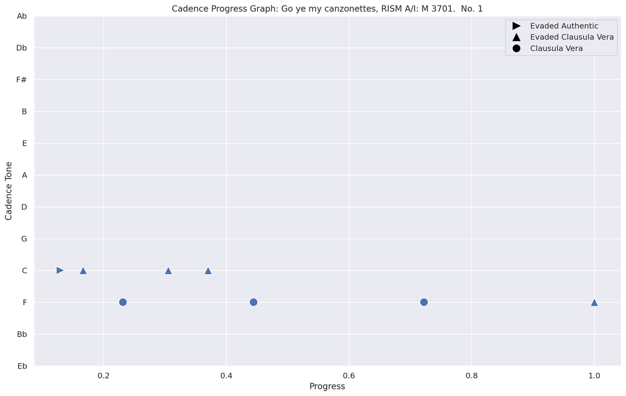

```python
# show 'progress' of cadences in that piece
piece = importScore(file_list[0])
piece.cadenceProgressPlot(includeType = True)
```